# ‘Plastic responses to metal contamination in a multistress context: a field experiment in fish’

Quentin PETITJEAN

25/06/2022

# 1 Load libraries

```r
library(lme4) # To build linear mixed effect model with binomial family
library(car) # To perform logit and power transformations and obtain p-value from linear mixed effect model
library(MuMIn) # To perform automated model selection based on AIC and compute conditional and marginal R square for mixed effect model
library(bimixt) # To transform data using bimixt::boxcox transformation (power transformation)
library(dplyr) # To manage the database (e.g., left_join, count)
library(tidyr) # To manage the database (e.g., separate)
library(performance) # check model performances
library(kableExtra) # To draw table
```

# 2 Load the dataset

```r
#dat1 <- read.csv2("https://github.com/qpetitjean/Plastic-responses-of-fish-in-a-multistress-context/blob/main/Dataset/Dataset_Petitjeanetal.-Adaptive_responses_of_fish_in_multistress_context.csv", dec = ".", sep = ";")
dat1 <- read.csv2(paste(getwd(),"Dataset_Petitjeanetal.-Adaptive_responses_of_fish_in_multistress_context.csv", sep = "/"), dec = ".", sep = ";")

# specify that the cage Id is a factor instead of numeric to use it as random intercept in mixed effect models
dat1[["CageSiteID"]] <- as.factor(dat1[["CageSiteID"]])

# Add merged treatments variables
dat1$CxOxI = paste(dat1$TransplantContam, dat1$OriginSite, dat1$Injection, sep = "_")
dat1$CxO2xI = paste(dat1$TransplantContam,
                    dat1$OriginContam,
                    dat1$Injection,
                    sep = "_")
dat1$CxO = paste(dat1$TransplantContam, dat1$OriginSite, sep = "_")
dat1$CxO2 = paste(dat1$TransplantContam, dat1$OriginContam, sep = "_")
dat1$CxI = paste(dat1$TransplantContam, dat1$Injection, sep = "_")
dat1$O2xI = paste(dat1$OriginContam, dat1$Injection, sep = "_")
head(dat1,5)
```

```
##     ColorMark IndID Escaped OriginSite CagingSite OriginContam     SitesPair
## 1    UNMARKED     1      No     AUSCOR     ARIMAS           HC AUSCOR_ARIMAS
## 2 WHITE_GREEN     2      No     AUSCOR     ARIMAS           HC AUSCOR_ARIMAS
## 3 PINK_ORANGE     3      No     AUSCOR     ARIMAS           HC AUSCOR_ARIMAS
## 4    PINK_RED     4      No     AUSCOR     ARIMAS           HC AUSCOR_ARIMAS
## 5  PINK_GREEN     5      No     AUSCOR     ARIMAS           HC AUSCOR_ARIMAS
##   CageID CageSiteID TransplantContam Transplant Injection  Treatment
## 1      6          6               LC      HC_LC      AMIX HC_LC_AMIX
## 2      6          6               LC      HC_LC      AMIX HC_LC_AMIX
## 3      6          6               LC      HC_LC       PBS  HC_LC_PBS
## 4      6          6               LC      HC_LC      AMIX HC_LC_AMIX
## 5      6          6               LC      HC_LC       PBS  HC_LC_PBS
##   WeightStart SizeStart Weight7D Size7D Weight9D Size9D WeightEnd SizeEnd
## 1         4.9       7.6      4.7    7.5      4.6    7.5       4.5     7.5
## 2         6.0       7.8      5.9    7.6      5.5    8.0       5.6     7.9
```

[output cut: 57 more lines]

# 3 Check sample size per treatments

## 3.1 Including escaped fish

```r
tab1 <- data.frame(table(dat1$OriginSite, dat1$CagingSite, dat1$OriginContam, dat1$TransplantContam, dat1$Injection))
names(tab1) <- c("Origin site", "Transplant site",  "Contamination level in origin site",   "Contamination level in transplant site",   "Immune challenge", "Sample size")
tab1 <- tab1[which(tab1[["Sample size"]]>0),]
tab1 <- tab1[order(tab1[["Origin site"]], tab1[["Transplant site"]]),]
rownames(tab1) <- NULL
kableExtra::kable_classic(kableExtra::kbl(tab1), bootstrap_options = c("striped", "hover", "condensed", "responsive"), full_width = F,  html_font = "arial", font_size = 10)
```

| Origin site | Transplant site | Contamination level in origin site | Contamination level in transplant site | Immune challenge | Sample size |
| --- | --- | --- | --- | --- | --- |
| ARIMAS | ARIMAS | LC | LC | AMIX | 18 |
| ARIMAS | ARIMAS | LC | LC | PBS | 15 |
| ARIMAS | AUSCOR | LC | HC | AMIX | 21 |
| ARIMAS | AUSCOR | LC | HC | PBS | 18 |
| AUSCOR | ARIMAS | HC | LC | AMIX | 18 |
| AUSCOR | ARIMAS | HC | LC | PBS | 17 |
| AUSCOR | AUSCOR | HC | HC | AMIX | 16 |
| AUSCOR | AUSCOR | HC | HC | PBS | 17 |
| CELFIG | CELFIG | LC | LC | AMIX | 17 |
| CELFIG | CELFIG | LC | LC | PBS | 16 |
| CELFIG | RIOU | LC | HC | AMIX | 17 |
| CELFIG | RIOU | LC | HC | PBS | 17 |
| RIOU | CELFIG | HC | LC | AMIX | 17 |
| RIOU | CELFIG | HC | LC | PBS | 16 |
| RIOU | RIOU | HC | HC | AMIX | 18 |
| RIOU | RIOU | HC | HC | PBS | 16 |

```r
# total sample size:
sum(tab1[["Sample size"]])
```

```
## [1] 274
```

## 3.2 Excluding escaped fish

```r
dat1bis = dat1[dat1$Escaped == "No", ]
tab2 <- data.frame(table(dat1bis$OriginSite, dat1bis$CagingSite, dat1bis$OriginContam, dat1bis$TransplantContam, dat1bis$Injection))
names(tab2) <- c("Origin site", "Transplant site",  "Contamination level in origin site",   "Contamination level in transplant site",   "Immune challenge", "Sample size")
tab2 <- tab2[which(tab2[["Sample size"]]>0),]
tab2 <- tab2[order(tab2[["Origin site"]], tab2[["Transplant site"]]),]
rownames(tab2) <- NULL
kableExtra::kable_classic(kableExtra::kbl(tab2), bootstrap_options = c("striped", "hover", "condensed", "responsive"), full_width = F,  html_font = "arial",  font_size = 10)
```

| Origin site | Transplant site | Contamination level in origin site | Contamination level in transplant site | Immune challenge | Sample size |
| --- | --- | --- | --- | --- | --- |
| ARIMAS | ARIMAS | LC | LC | AMIX | 18 |
| ARIMAS | ARIMAS | LC | LC | PBS | 15 |
| ARIMAS | AUSCOR | LC | HC | AMIX | 20 |
| ARIMAS | AUSCOR | LC | HC | PBS | 18 |
| AUSCOR | ARIMAS | HC | LC | AMIX | 18 |
| AUSCOR | ARIMAS | HC | LC | PBS | 17 |
| AUSCOR | AUSCOR | HC | HC | AMIX | 15 |
| AUSCOR | AUSCOR | HC | HC | PBS | 14 |
| CELFIG | CELFIG | LC | LC | AMIX | 17 |
| CELFIG | CELFIG | LC | LC | PBS | 16 |
| CELFIG | RIOU | LC | HC | AMIX | 17 |
| CELFIG | RIOU | LC | HC | PBS | 17 |
| RIOU | CELFIG | HC | LC | AMIX | 17 |
| RIOU | CELFIG | HC | LC | PBS | 15 |
| RIOU | RIOU | HC | HC | AMIX | 18 |
| RIOU | RIOU | HC | HC | PBS | 16 |

```r
# total sample size:
sum(tab2[["Sample size"]])
```

```
## [1] 268
```

# 4 Test some basics

here we will test the design of the experiment.  
A quick reminder:

- Treatments (fixed effects):
  - TransplantContam (transplant treatment either High contamination-HC or Low contamination-LC)
  - OriginContam (Origin of the population either High contamination-HC or Low contamination-LC)
  - Injection (control saline: PBS, antigen mixture: AMIX)
- Covariates :
  - SizeEnd (Fish size at the end of the experiment)
  - Sex (Fish sex determined by visual inspection at the end of the experiment)
- Blocks (random effects):
  - CagingSite (The name of the study site where fish are caged, either ARIMAS, AUSCOR, CELFIG or RIOU)
  - CageSiteID (The ID number ranging from 1 to 6 corresponding to the number of the cage within each study site)
  - OriginSite (The name of the site where each population were sampled = population ID)

## 4.1 Test Distribution of fish sex among cages

sex determination was performed at the end of the experiment: visual inspection of the gonads

```r
dat2 = dat1[is.na(dat1$Sex) == F, ]
sexTabCage = table(dat2$CageID, dat2$Sex)
sexTabOrigin = table(dat2$OriginContam, dat2$Sex)
sexTabTransplant = table(dat2$TransplantContam, dat2$Sex)
sexTabInj = table(dat2$Injection, dat2$Sex)
sexTabTriple = table(dat2$CxO2xI, dat2$Sex)
```

### 4.1.1 Visualize the data

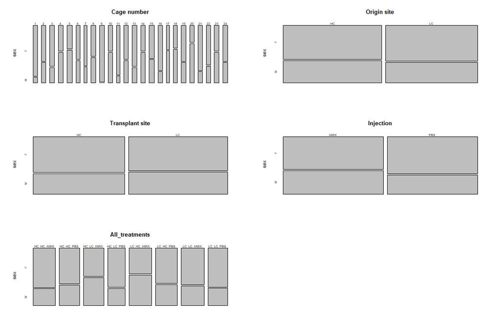

```r
par(mfrow=c(3,2))
plot(sexTabCage, main = "Cage number", ylab = "sex")
plot(sexTabOrigin, main = "Origin site", ylab = "sex")
plot(sexTabTransplant, main = "Transplant site", ylab = "sex")
plot(sexTabInj, main = "Injection", ylab = "sex")
plot(sexTabTriple, main = "All_treatments", ylab = "sex")
```

### Test sex distribution among cages using Chi square test

```r
chi = chisq.test(sexTabCage)
contrib <- 100 * chi$residuals ^ 2 / chi$statistic
chi
```

```
##
##  Pearson's Chi-squared test
##
## data:  sexTabCage
## X-squared = 31.578, df = 23, p-value = 0.1093
```

While some cages contains more female than male, the global pattern is not significant  
since Chi-squared approximation may be incorrect, run fisher exact test to confirm this result :

```r
fisher.test(sexTabCage, simulate.p.value = TRUE)
```

```
##
##  Fisher's Exact Test for Count Data with simulated p-value (based on
##  2000 replicates)
##
## data:  sexTabCage
## p-value = 0.07546
## alternative hypothesis: two.sided
```

Fisher test is non-significant, which confirm the result of the Chisquare-test

### 4.1.2 What about sex distribution among treatments: origin ?

```r
chi = chisq.test(sexTabOrigin)
contrib <- 100 * chi$residuals ^ 2 / chi$statistic
chi
```

```
##
##  Pearson's Chi-squared test with Yates' continuity correction
##
## data:  sexTabOrigin
## X-squared = 0.11037, df = 1, p-value = 0.7397
```

As observed on the plot and as confirmed by chisquare test,  
distribution of male and female is balanced among populations origin

### 4.1.3 What about sex distribution among treatments: TransplantContam ?

```r
chi = chisq.test(sexTabTransplant)
contrib <- 100 * chi$residuals ^ 2 / chi$statistic
chi
```

```
##
##  Pearson's Chi-squared test with Yates' continuity correction
##
## data:  sexTabTransplant
## X-squared = 0.11037, df = 1, p-value = 0.7397
```

As observed on the plot and as confirmed by chisquare test,  
distribution of male and female is balanced between TransplantContam treatments

### 4.1.4 What about sex distribution among treatments: Injection ?

```r
chi = chisq.test(sexTabInj)
contrib <- 100 * chi$residuals ^ 2 / chi$statistic
chi
```

```
##
##  Pearson's Chi-squared test with Yates' continuity correction
##
## data:  sexTabInj
## X-squared = 1.3894, df = 1, p-value = 0.2385
```

As observed on the plot and as confirmed by chisquare test,  
distribution of male and female is balanced between Injection treatments

### 4.1.5 What about sex distribution among treatments: triple combination of treatments ?

```r
chi = chisq.test(sexTabTriple)
contrib <- 100 * chi$residuals ^ 2 / chi$statistic
chi
```

```
##
##  Pearson's Chi-squared test
##
## data:  sexTabTriple
## X-squared = 7.7457, df = 7, p-value = 0.3556
```

As observed on the plot and as confirmed by chisquare test,  
distribution of male and female is more or less balanced among treatments

## 4.2 Test distribution of fish weight among treatments (at the beginning of the experiment, using WeightStart)

Visualize the data

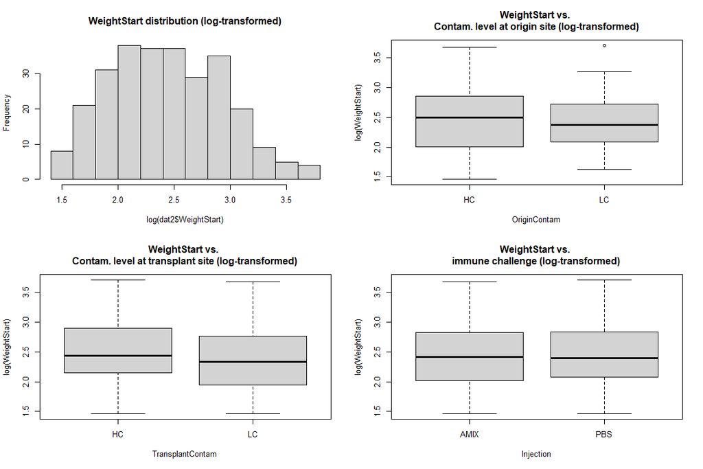

```r
dat2 <- dat1[is.na(dat1$WeightStart) == F, ]
par(mfrow = c(2, 2))
hist(log(dat2$WeightStart),
     main = "WeightStart distribution (log-transformed)")
boxplot(log(WeightStart) ~ OriginContam,
        data = dat2,
        main = "WeightStart vs. \nContam. level at origin site (log-transformed)")
boxplot(log(WeightStart) ~ TransplantContam,
        data = dat2,
        main = "WeightStart vs. \nContam. level at transplant site (log-transformed)")
boxplot(log(WeightStart) ~ Injection,
        data = dat2,
        main = "WeightStart vs. \nimmune challenge (log-transformed)")
```

Create the full model

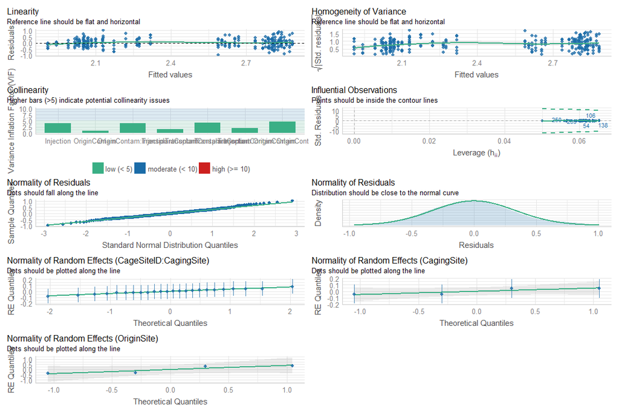

```r
mod1 <- lme4::lmer(
  log(WeightStart) ~ TransplantContam * OriginContam * Injection +
  (1 | CagingSite / CageSiteID) + (1 | OriginSite),
  data = dat2
)
performance::check_model(mod1)
```

```r
car::Anova(mod1, type = "3")
```

```
## Analysis of Deviance Table (Type III Wald chisquare tests)
##
## Response: log(WeightStart)
##                                           Chisq Df Pr(>Chisq)
## (Intercept)                             49.1325  1  2.392e-12 ***
## TransplantContam                         0.7673  1     0.3810
## OriginContam                             0.0335  1     0.8548
## Injection                                0.2716  1     0.6023
## TransplantContam:OriginContam            0.0575  1     0.8104
## TransplantContam:Injection               0.0075  1     0.9308
## OriginContam:Injection                   0.0177  1     0.8941
## TransplantContam:OriginContam:Injection  0.0003  1     0.9871
## ---
## Signif. codes:  0 '***' 0.001 '**' 0.01 '*' 0.05 '.' 0.1 ' ' 1
```

```r
summary(mod1)
```

```
## Linear mixed model fit by REML ['lmerMod']
## Formula: log(WeightStart) ~ TransplantContam * OriginContam * Injection +
##     (1 | CagingSite/CageSiteID) + (1 | OriginSite)
##    Data: dat2
##
## REML criterion at convergence: 233.5
##
## Scaled residuals:
##      Min       1Q   Median       3Q      Max
## -2.79246 -0.64175 -0.02739  0.62911  2.92879
##
## Random effects:
##  Groups                Name        Variance Std.Dev.
##  CageSiteID:CagingSite (Intercept) 0.005362 0.07323
##  CagingSite            (Intercept) 0.009039 0.09507
##  OriginSite            (Intercept) 0.238754 0.48863
##  Residual                          0.117980 0.34348
## Number of obs: 274, groups:
## CageSiteID:CagingSite, 24; CagingSite, 4; OriginSite, 4
##
## Fixed effects:
##                                                 Estimate Std. Error t value
## (Intercept)                                     2.510397   0.358144   7.009
## TransplantContamLC                             -0.116490   0.132982  -0.876
## OriginContamLC                                 -0.090998   0.497147  -0.183
## InjectionPBS                                    0.043809   0.084066   0.521
## TransplantContamLC:OriginContamLC               0.031222   0.130154   0.240
## TransplantContamLC:InjectionPBS                -0.010287   0.118470  -0.087
## OriginContamLC:InjectionPBS                    -0.015510   0.116522  -0.133
## TransplantContamLC:OriginContamLC:InjectionPBS -0.002688   0.166541  -0.016
##
## Correlation of Fixed Effects:
##             (Intr) TrnCLC OrgCLC InjPBS TrCLC:OCLC TCLC:I OCLC:I
## TrnsplntCLC -0.187
## OrignCntmLC -0.695  0.066
## InjectinPBS -0.116  0.312  0.083
## TrnCLC:OCLC  0.094 -0.500 -0.130 -0.319
## TrnCLC:IPBS  0.082 -0.436 -0.059 -0.710  0.445
## OrgCLC:IPBS  0.083 -0.225 -0.114 -0.722  0.436      0.512
## TCLC:OCLC:I -0.058  0.310  0.080  0.505 -0.617     -0.712 -0.700
```

now, refine the model using AIC

```r
mod1 =lme4::lmer(
  log(WeightStart) ~ TransplantContam * OriginContam * Injection +
  (1 | CagingSite / CageSiteID) + (1 | OriginSite),
  data = dat2,
  REML = FALSE,
  na.action = "na.fail"
)
MuMIn::dredge(mod1, rank = "AIC")
```

```
## Global model call: lme4::lmer(formula = log(WeightStart) ~ TransplantContam * OriginContam *
##     Injection + (1 | CagingSite/CageSiteID) + (1 | OriginSite),
##     data = dat2, REML = FALSE, na.action = "na.fail")
## ---
## Model selection table
##     (Int) Inj OrC TrC Inj:OrC Inj:TrC OrC:TrC Inj:OrC:TrC df   logLik   AIC
## 1   2.429                                                  5 -108.035 226.1
## 5   2.483           +                                      6 -107.337 226.7
## 2   2.414   +                                              6 -107.764 227.5
## 3   2.471       +                                          6 -108.007 228.0
## 6   2.468   +       +                                      7 -107.065 228.1
## 7   2.524       +   +                                      7 -107.308 228.6
## 4   2.456   +   +                                          7 -107.736 229.5
## 8   2.509   +   +   +                                      8 -107.037 230.1
## 22  2.465   +       +               +                      8 -107.056 230.1
```

[output cut: 33 more lines]

The best model is the null model meaning that fish mass were not significantly different among treatments  
run the model with simple treatments effect to obtain NS p-value (reported in material & methods)

```r
mod2 = lme4::lmer(
  log(WeightStart) ~ TransplantContam + OriginContam + Injection +
  (1 | CagingSite / CageSiteID) + (1 | OriginSite),
  data = dat2,
)
car::Anova(mod2, type = "3")
```

```
## Analysis of Deviance Table (Type III Wald chisquare tests)
##
## Response: log(WeightStart)
##                    Chisq Df Pr(>Chisq)
## (Intercept)      49.8378  1   1.67e-12 ***
## TransplantContam  0.9723  1     0.3241
## OriginContam      0.0290  1     0.8649
## Injection         0.5419  1     0.4617
## ---
## Signif. codes:  0 '***' 0.001 '**' 0.01 '*' 0.05 '.' 0.1 ' ' 1
```

```r
summary(mod2)
```

```
## Linear mixed model fit by REML ['lmerMod']
## Formula: log(WeightStart) ~ TransplantContam + OriginContam + Injection +
##     (1 | CagingSite/CageSiteID) + (1 | OriginSite)
##    Data: dat2
##
## REML criterion at convergence: 222.9
##
## Scaled residuals:
##      Min       1Q   Median       3Q      Max
## -2.77716 -0.63120 -0.03151  0.63460  2.92805
##
## Random effects:
##  Groups                Name        Variance Std.Dev.
##  CageSiteID:CagingSite (Intercept) 0.004712 0.06864
##  CagingSite            (Intercept) 0.009156 0.09569
##  OriginSite            (Intercept) 0.238929 0.48880
##  Residual                          0.116574 0.34143
## Number of obs: 274, groups:
## CageSiteID:CagingSite, 24; CagingSite, 4; OriginSite, 4
##
## Fixed effects:
##                    Estimate Std. Error t value
## (Intercept)         2.50934    0.35545   7.060
## TransplantContamLC -0.10643    0.10793  -0.986
## OriginContamLC     -0.08362    0.49135  -0.170
## InjectionPBS        0.03044    0.04135   0.736
##
## Correlation of Fixed Effects:
##             (Intr) TrnCLC OrgCLC
## TrnsplntCLC -0.152
## OrignCntmLC -0.691  0.001
## InjectinPBS -0.057  0.004  0.001
```

Compute mean and Sd of fish Weight (reported in material & methods)

```r
mean(dat2$WeightStart)
```

```
## [1] 12.93686
```

```r
sd(dat2$WeightStart)
```

```
## [1] 6.933831
```

## 4.3 Test Distribution of fish size among treatments (at the beginning of the experiment, using SizeStart)

Visualize the data

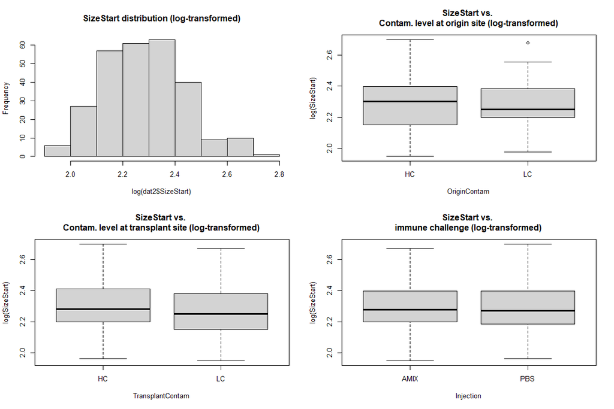

```r
dat2 = dat1[is.na(dat1$SizeStart) == F, ]
par(mfrow = c(2, 2))
hist(log(dat2$SizeStart),
     main = "SizeStart distribution (log-transformed)")
boxplot(log(SizeStart) ~ OriginContam,
        data = dat2,
        main = "SizeStart vs. \nContam. level at origin site (log-transformed)")
boxplot(log(SizeStart) ~ TransplantContam,
        data = dat2,
        main = "SizeStart vs. \nContam. level at transplant site (log-transformed)")
boxplot(log(SizeStart) ~ Injection,
        data = dat2,
        main = "SizeStart vs. \nimmune challenge (log-transformed)")
```

Create the full model

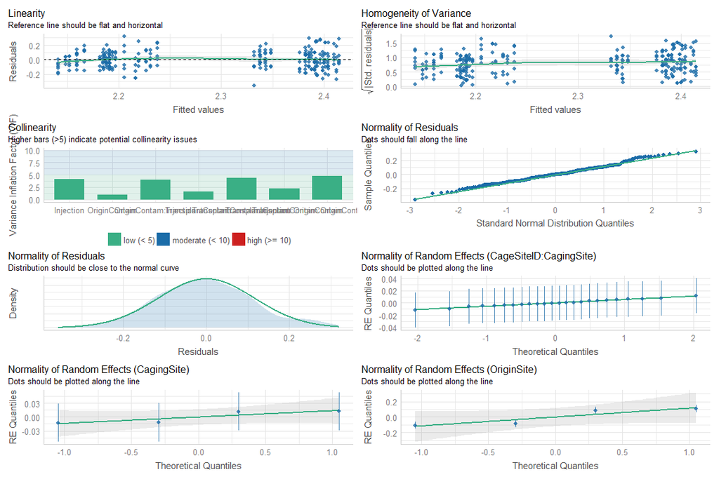

```r
mod1 <- lme4::lmer(
  log(SizeStart) ~ TransplantContam * OriginContam * Injection +
  (1 | CagingSite / CageSiteID) + (1 | OriginSite),
  data = dat2
)
performance::check_model(mod1)
```

```r
car::Anova(mod1, type = "3")
```

```
## Analysis of Deviance Table (Type III Wald chisquare tests)
##
## Response: log(SizeStart)
##                                            Chisq Df Pr(>Chisq)
## (Intercept)                             509.4453  1     <2e-16 ***
## TransplantContam                          0.8929  1     0.3447
## OriginContam                              0.0191  1     0.8900
## Injection                                 0.1480  1     0.7005
## TransplantContam:OriginContam             0.0666  1     0.7964
## TransplantContam:Injection                0.0073  1     0.9318
## OriginContam:Injection                    0.1812  1     0.6703
## TransplantContam:OriginContam:Injection   0.0679  1     0.7945
## ---
## Signif. codes:  0 '***' 0.001 '**' 0.01 '*' 0.05 '.' 0.1 ' ' 1
```

```r
summary(mod1)
```

```
## Linear mixed model fit by REML ['lmerMod']
## Formula: log(SizeStart) ~ TransplantContam * OriginContam * Injection +
##     (1 | CagingSite/CageSiteID) + (1 | OriginSite)
##    Data: dat2
##
## REML criterion at convergence: -336.1
##
## Scaled residuals:
##      Min       1Q   Median       3Q      Max
## -3.01022 -0.72980 -0.01529  0.62898  2.69373
##
## Random effects:
##  Groups                Name        Variance  Std.Dev.
##  CageSiteID:CagingSite (Intercept) 0.0002450 0.01565
##  CagingSite            (Intercept) 0.0007335 0.02708
##  OriginSite            (Intercept) 0.0192863 0.13888
##  Residual                          0.0141330 0.11888
## Number of obs: 274, groups:
## CageSiteID:CagingSite, 24; CagingSite, 4; OriginSite, 4
##
## Fixed effects:
##                                                 Estimate Std. Error t value
## (Intercept)                                     2.309201   0.102309  22.571
## TransplantContamLC                             -0.038222   0.040448  -0.945
## OriginContamLC                                 -0.019636   0.141983  -0.138
## InjectionPBS                                    0.011188   0.029083   0.385
## TransplantContamLC:OriginContamLC               0.010833   0.041983   0.258
## TransplantContamLC:InjectionPBS                -0.003507   0.040977  -0.086
## OriginContamLC:InjectionPBS                    -0.017157   0.040302  -0.426
## TransplantContamLC:OriginContamLC:InjectionPBS  0.015005   0.057604   0.260
##
## Correlation of Fixed Effects:
##             (Intr) TrnCLC OrgCLC InjPBS TrCLC:OCLC TCLC:I OCLC:I
## TrnsplntCLC -0.199
## OrignCntmLC -0.695  0.080
## InjectinPBS -0.140  0.354  0.101
## TrnCLC:OCLC  0.107 -0.532 -0.146 -0.342
## TrnCLC:IPBS  0.099 -0.496 -0.072 -0.710  0.478
## OrgCLC:IPBS  0.101 -0.256 -0.138 -0.722  0.468      0.512
## TCLC:OCLC:I -0.071  0.353  0.097  0.505 -0.662     -0.712 -0.700
```

now, refine the model using AIC

```r
mod1 =lme4::lmer(
  log(SizeStart) ~ TransplantContam * OriginContam * Injection +
  (1 | CagingSite / CageSiteID) + (1 | OriginSite),
  data = dat2,
  REML = FALSE,
  na.action = "na.fail"
)
MuMIn::dredge(mod1, rank = "AIC")
```

```
## Global model call: lme4::lmer(formula = log(SizeStart) ~ TransplantContam * OriginContam *
##     Injection + (1 | CagingSite/CageSiteID) + (1 | OriginSite),
##     data = dat2, REML = FALSE, na.action = "na.fail")
## ---
## Model selection table
##     (Int) Inj OrC TrC Inj:OrC Inj:TrC OrC:TrC Inj:OrC:TrC df  logLik    AIC
## 1   2.285                                                  5 185.981 -362.0
## 5   2.301           +                                      6 186.677 -361.4
## 2   2.283   +                                              6 186.029 -360.1
## 3   2.295       +                                          6 185.999 -360.0
## 6   2.299   +       +                                      7 186.724 -359.4
## 7   2.310       +   +                                      7 186.695 -359.4
## 4   2.292   +   +                                          7 186.047 -358.1
## 39  2.315       +   +                       +              8 186.863 -357.7
## 8   2.308   +   +   +                                      8 186.742 -357.5
```

[output cut: 33 more lines]

The best model is the null model meaning that fish mass were not significantly different among treatments  
run the model with simple treatments effect to obtain NS p-value (reported in material & methods)

```r
mod2 = lme4::lmer(
  log(SizeStart) ~ TransplantContam + OriginContam + Injection +
  (1 | CagingSite / CageSiteID) + (1 | OriginSite),
  data = dat2,
)
car::Anova(mod2, type = "3")
```

```
## Analysis of Deviance Table (Type III Wald chisquare tests)
##
## Response: log(SizeStart)
##                     Chisq Df Pr(>Chisq)
## (Intercept)      519.3942  1     <2e-16 ***
## TransplantContam   0.9642  1     0.3261
## OriginContam       0.0186  1     0.8916
## Injection          0.0953  1     0.7575
## ---
## Signif. codes:  0 '***' 0.001 '**' 0.01 '*' 0.05 '.' 0.1 ' ' 1
```

```r
summary(mod2)
```

```
## Linear mixed model fit by REML ['lmerMod']
## Formula: log(SizeStart) ~ TransplantContam + OriginContam + Injection +
##     (1 | CagingSite/CageSiteID) + (1 | OriginSite)
##    Data: dat2
##
## REML criterion at convergence: -355
##
## Scaled residuals:
##      Min       1Q   Median       3Q      Max
## -3.00146 -0.72982 -0.02693  0.63527  2.70416
##
## Random effects:
##  Groups                Name        Variance  Std.Dev.
##  CageSiteID:CagingSite (Intercept) 0.0002086 0.01444
##  CagingSite            (Intercept) 0.0007474 0.02734
##  OriginSite            (Intercept) 0.0193006 0.13893
##  Residual                          0.0139709 0.11820
## Number of obs: 274, groups:
## CageSiteID:CagingSite, 24; CagingSite, 4; OriginSite, 4
##
## Fixed effects:
##                     Estimate Std. Error t value
## (Intercept)         2.307936   0.101269  22.790
## TransplantContamLC -0.030846   0.031412  -0.982
## OriginContamLC     -0.019052   0.139785  -0.136
## InjectionPBS        0.004417   0.014307   0.309
##
## Correlation of Fixed Effects:
##             (Intr) TrnCLC OrgCLC
## TrnsplntCLC -0.156
## OrignCntmLC -0.691  0.001
## InjectinPBS -0.070  0.004  0.001
```

Compute mean and Sd of fish size (reported in material & methods)

```r
mean(dat2$SizeStart)
```

```
## [1] 9.962044
```

```r
sd(dat2$SizeStart)
```

```
## [1] 1.589071
```

## 4.4 Test for Crowding

### 4.4.1 Compute mean and Sd of fish density per liter (reported in material & methods)

- At the start of the experiment

```r
Crowd = aggregate(dat1$WeightStart, list(dat1$CageID), sum)
Crowd$dens = Crowd$x / 130 # 130 is the volume of the cages in liters
mean(Crowd$dens) # expressed in grams of fish per liter of water within the cage
```

```
## [1] 1.136122
```

```r
sd(Crowd$dens)
```

```
## [1] 0.4599962
```

- At the end of the experiment

```r
dat2 = dat1[is.na(dat1$Death) == F, ]
dat2 = dat2[-c(which(dat2$Death == 1)), ]
Crowd2 = aggregate(dat2$WeightEnd, list(dat2$CageID), function(x)
  sum(x, na.rm = T))
Crowd2$dens = Crowd2$x / 130 # 130 is the volume of the cages in liters
mean(Crowd2$dens)
```

```
## [1] 0.9001603
```

```r
sd(Crowd2$dens)
```

```
## [1] 0.3783853
```

### 4.4.2 Test for the difference between start and end of the experiment

```r
CrowdTest = cbind(Crowd$dens, Crowd2$dens)
chi = chisq.test(CrowdTest)
contrib <- 100 * chi$residuals ^ 2 / chi$statistic
chi
```

```
##
##  Pearson's Chi-squared test
##
## data:  CrowdTest
## X-squared = 0.47726, df = 23, p-value = 1
```

```r
# Here the test confirmed that density of fish is not significantly different among cages
# but since Chi-squared approximation may be incorrect, run fisher exact test to confirm this result :
fisher.test(round(CrowdTest, 1)*10, simulate.p.value = TRUE) # Round values to the first decimal and multiply by 10 to have integer only (necessary for fisher-test)
```

```
##
##  Fisher's Exact Test for Count Data with simulated p-value (based on
##  2000 replicates)
##
## data:  round(CrowdTest, 1) * 10
## p-value = 1
## alternative hypothesis: two.sided
```

Fisher test is non-significant, confirming the result of the Chisquare-test: The density of fish is not significantly different among cages between the start and end of the experiment, hence, While there was some death in several cages, the global pattern is not significant

## 4.5 Check Toxic Unit (TU) consistency among studies and between the start and end of the experiment

Retrieve the TU reported in PETITJEAN et al. 2020 a,b (based on water agency database)

```r
Tu2020 = c(-0.9,-0.9,-0.3, 1.3)
```

Retrieve the global TU reported in the present study  
based on water samples collected in this study, both at the start and end of the experiment

```r
TuStart = c(-0.4,-0.5,-0.1, 1.1)
TuEnd = c(-0.3,-0.7, 0.3, 0.9)
TuGlobal = c(-0.4,-0.6, 0.2, 1.0)
Tutab = cbind(Tu2020, TuGlobal)
Tutab2 = cbind(TuStart, TuEnd)
```

### 4.5.1 Visualize

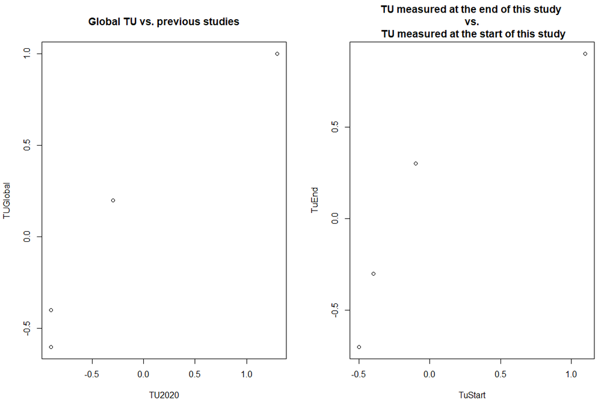

```r
par(mfrow = c(1, 2))
plot(Tutab,
     xlab = "TU2020",
     ylab = "TUGlobal",
     main = "Global TU vs. previous studies")
plot(Tutab2,
     xlab = "TuStart",
     ylab = "TuEnd",
     main = "TU measured at the end of this study \n vs. \n TU measured at the start of this study")
```

### 4.5.2 Test the difference among global and TU reported in this study and reported in PETITJEAN et al. 2020 a,b

```r
chi = chisq.test(Tutab + 1) # add 1 to each values to ensure TU is positive (necessary for chi-test)
contrib <- 100 * chi$residuals ^ 2 / chi$statistic
chi
```

```
##
##  Pearson's Chi-squared test
##
## data:  Tutab + 1
## X-squared = 0.56483, df = 3, p-value = 0.9044
```

```r
# Here the test confirmed that Toxic units are not significantly different among studies
# but since Chi-squared approximation may be incorrect, run fisher exact test to confirm this result :
fisher.test((Tutab + 1)*10, simulate.p.value = TRUE) # add 1 to each values to ensure TU is positive and multiply by 10 to have integer only (necessary for fisher-test)
```

```
##
##  Fisher's Exact Test for Count Data with simulated p-value (based on
##  2000 replicates)
##
## data:  (Tutab + 1) * 10
## p-value = 0.1449
## alternative hypothesis: two.sided
```

Fisher test is non-significant, confirming the result of the Chisquare-test: The toxic units are not significantly different among studies

### 4.5.3 Test the difference in Toxic Unit between the start and the end of the experiment

```r
chi = chisq.test(Tutab2 + 1) # add 1 to each values to ensure TU is positive (necessary for chi-test)
contrib <- 100 * chi$residuals ^ 2 / chi$statistic
chi
```

```
##
##  Pearson's Chi-squared test
##
## data:  Tutab2 + 1
## X-squared = 0.13923, df = 3, p-value = 0.9867
```

```r
# Here the test confirmed that Toxic units are not significantly different between the start and the end of the experiment
# but since Chi-squared approximation may be incorrect, run fisher exact test to confirm this result :
fisher.test((Tutab2 + 1)*10, simulate.p.value = TRUE) # add 1 to each values to ensure TU is positive and multiply by 10 to have integer only (necessary for fisher-test)
```

```
##
##  Fisher's Exact Test for Count Data with simulated p-value (based on
##  2000 replicates)
##
## data:  (Tutab2 + 1) * 10
## p-value = 0.7191
## alternative hypothesis: two.sided
```

Fisher test is non-significant, confirming the result of the Chisquare-test: the toxic units are not significantly different between the start and the end of the experiment

# 5 Data analyses

A quick reminder:

- Treatments (fixed effects):
  - TransplantContam (transplant treatment either High contamination-HC or Low contamination-LC)
  - OriginContam (Origin of the population either High contamination-HC or Low contamination-LC)
  - Injection (control saline: PBS, antigen mixture: AMIX)
- Covariates :
  - SizeEnd (Fish size at the end of the experiment)
  - Sex (Fish sex determined by visual inspection at the end of the experiment)
- Blocks (random effects):
  - CagingSite (The name of the study site where fish are caged, either ARIMAS, AUSCOR, CELFIG or RIOU)
  - CageSiteID (The ID number ranging from 1 to 6 corresponding to the number of the cage within each study site)
  - OriginSite (The name of the site where each population were sampled = population ID)

Here we used The identity of the cage nested within the study site as random effects  
to consider possible shared conditions within the cage and the study site.

Best models were selected by backward selection procedure, eliminating non-significant interactions and variables (i.e., p-value > 0.05).

When interactions were found significant, we analyzed differences between groups using pairwise t-test with false discovery rate adjustment (Benjamini and Hochberg, 1995) or two-sample fisher’s exact test for count data (i.e., survival) (Agresti, 2007), respectively.

In addition, when interactions between the level of contamination in the transplant site and the origin of the population (i.e., HC or LC) were significant, we tested whether slopes were parallel among replicates populations by comparing models including the level of contamination in transplant site (i.e., HC or LC) and the identity of the origin of the population (i.e., ARIMAS, AUSCOR or CELFIG, RIOU) with models including the interaction between the level of contamination in transplant site and the identity of the origin of the population according to (Jacquin et al., 2016).

NB: The results retrieved from the following refined models are reported in Table 3 of the manuscript. The table 3 can also be found in the section “Summary of the best models (Table 3 from the manuscript)”

## 5.1 Survival

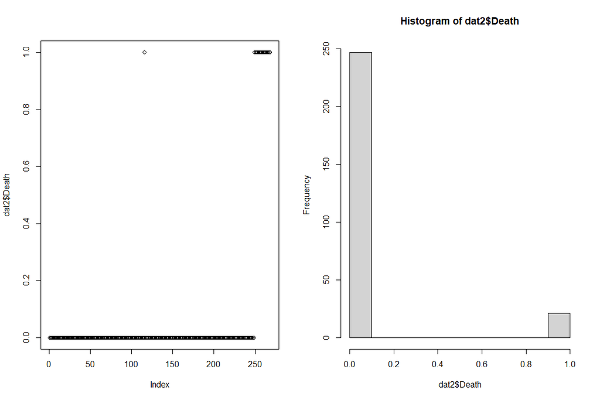

```r
dat2 = dat1[is.na(dat1$Death) == F, ]
par(mfrow = c(1,2))
plot(dat2$Death)
hist(dat2$Death)
```

The data are binomial, so use glmer function from lme4 package to construct the full model: ### Use GLMER with family binomial

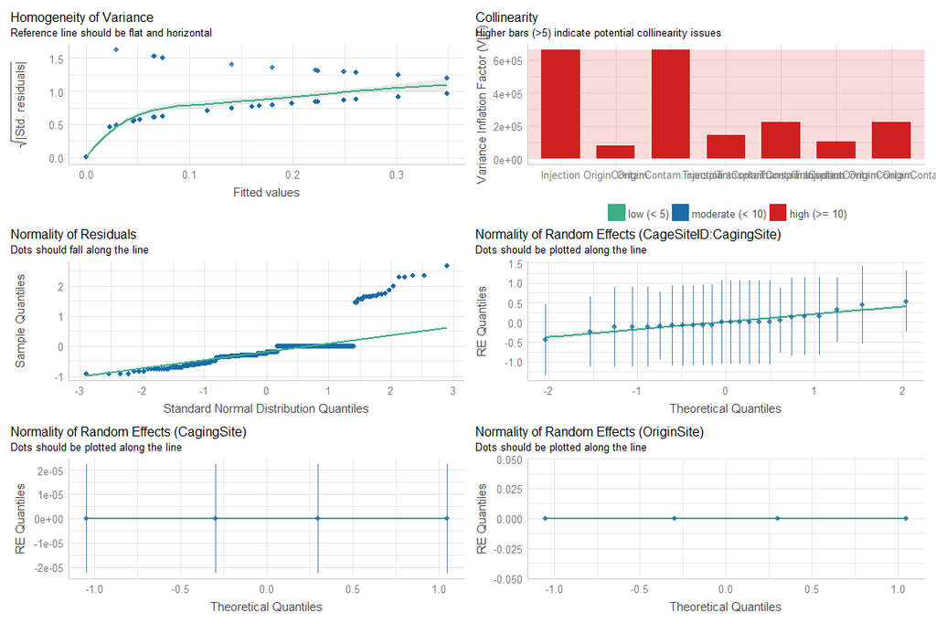

```r
modfull <-
  lme4::glmer(
    Death ~ (TransplantContam + OriginContam + Injection) ^ 3 + (1 | CagingSite /  CageSiteID) + (1| OriginSite),
    data = dat2,
    family = binomial(link = "logit"),
    na.action = na.fail
  )
performance::check_model(modfull)
```

```r
car::Anova(modfull, type = "3")
```

```
## Analysis of Deviance Table (Type III Wald chisquare tests)
##
## Response: Death
##                                          Chisq Df Pr(>Chisq)
## (Intercept)                             0.0083  1     0.9273
## TransplantContam                        0.0062  1     0.9373
## OriginContam                            0.0072  1     0.9326
## Injection                               0.0000  1     0.9997
## TransplantContam:OriginContam           0.0077  1     0.9303
## TransplantContam:Injection              0.0023  1     0.9621
## OriginContam:Injection                  0.0000  1     0.9989
## TransplantContam:OriginContam:Injection 0.0024  1     0.9612
```

```r
summary(modfull)
```

```
## Generalized linear mixed model fit by maximum likelihood (Laplace
##   Approximation) [glmerMod]
##  Family: binomial  ( logit )
## Formula: Death ~ (TransplantContam + OriginContam + Injection)^3 + (1 |
##     CagingSite/CageSiteID) + (1 | OriginSite)
##    Data: dat2
##
##      AIC      BIC   logLik deviance df.resid
##    136.3    175.8    -57.2    114.3      257
##
## Scaled residuals:
##     Min      1Q  Median      3Q     Max
## -0.7322 -0.2658 -0.1625  0.0000  5.7648
##
## Random effects:
##  Groups                Name        Variance  Std.Dev.
##  CageSiteID:CagingSite (Intercept) 2.912e-01 5.396e-01
##  CagingSite            (Intercept) 1.310e-10 1.144e-05
##  OriginSite            (Intercept) 0.000e+00 0.000e+00
## Number of obs: 268, groups:
## CageSiteID:CagingSite, 24; CagingSite, 4; OriginSite, 4
##
## Fixed effects:
##                                                Estimate Std. Error z value
## (Intercept)                                    -21.4406   235.0225  -0.091
## TransplantContamLC                              18.4876   235.0224   0.079
## OriginContamLC                                  19.8733   235.0222   0.085
## InjectionPBS                                    -0.1350   406.2111   0.000
## TransplantContamLC:OriginContamLC              -20.5680   235.0231  -0.088
## TransplantContamLC:InjectionPBS                -18.6017   391.4285  -0.048
## OriginContamLC:InjectionPBS                      0.5503   406.2112   0.001
## TransplantContamLC:OriginContamLC:InjectionPBS  19.0396   391.4280   0.049
##                                                Pr(>|z|)
## (Intercept)                                       0.927
## TransplantContamLC                                0.937
## OriginContamLC                                    0.933
## InjectionPBS                                      1.000
## TransplantContamLC:OriginContamLC                 0.930
## TransplantContamLC:InjectionPBS                   0.962
## OriginContamLC:InjectionPBS                       0.999
## TransplantContamLC:OriginContamLC:InjectionPBS    0.961
##
## Correlation of Fixed Effects:
##             (Intr) TrnCLC OrgCLC InjPBS TrCLC:OCLC TCLC:I OCLC:I
## TrnsplntCLC -1.000
## OrignCntmLC -1.000  1.000
## InjectinPBS -0.020  0.020  0.020
## TrnCLC:OCLC  1.000 -1.000 -1.000 -0.020
## TrnCLC:IPBS -0.019  0.019  0.019 -0.148 -0.019
## OrgCLC:IPBS  0.020 -0.020 -0.020 -1.000  0.020      0.148
## TCLC:OCLC:I  0.019 -0.019 -0.019  0.148  0.019     -1.000 -0.148
## optimizer (Nelder_Mead) convergence code: 0 (OK)
## boundary (singular) fit: see ?isSingular
```

```r
MuMIn::r.squaredGLMM(modfull)
```

```
##                   R2m       R2c
## theoretical 0.9595305 0.9628213
## delta       0.8477609 0.8506684
```

The model returns a singular fit, the random structure seems too complex for the data since “OriginSite” have a variance of zero. To solve this, we can use two alternative methods:

### 5.1.1 Use classic glm with family binomial (remove random effects)

```r
modfull <-
  glm(
    Death ~ (TransplantContam + OriginContam + Injection) ^ 3,
    data = dat2,
    family = "binomial"
  )
car::Anova(modfull, type = "3")
```

```
## Analysis of Deviance Table (Type III tests)
##
## Response: Death
##                                         LR Chisq Df Pr(>Chisq)
## TransplantContam                          2.7138  1   0.099486 .
## OriginContam                              9.6183  1   0.001927 **
## Injection                                 0.0000  1   1.000000
## TransplantContam:OriginContam             6.2985  1   0.012084 *
## TransplantContam:Injection                0.0000  1   1.000000
## OriginContam:Injection                    0.0000  1   0.999960
## TransplantContam:OriginContam:Injection   0.0000  1   1.000000
## ---
## Signif. codes:  0 '***' 0.001 '**' 0.01 '*' 0.05 '.' 0.1 ' ' 1
```

```r
summary(modfull)
```

```
##
## Call:
## glm(formula = Death ~ (TransplantContam + OriginContam + Injection)^3,
##     family = "binomial", data = dat2)
##
## Deviance Residuals:
##      Min        1Q    Median        3Q       Max
## -0.77104  -0.36522  -0.24078  -0.00008   2.66659
##
## Coefficients:
##                                                  Estimate Std. Error z value
## (Intercept)                                    -1.957e+01  1.872e+03  -0.010
## TransplantContamLC                              1.676e+01  1.872e+03   0.009
## OriginContamLC                                  1.811e+01  1.872e+03   0.010
## InjectionPBS                                   -9.667e-09  2.713e+03   0.000
## TransplantContamLC:OriginContamLC              -1.883e+01  1.872e+03  -0.010
## TransplantContamLC:InjectionPBS                -1.676e+01  3.313e+03  -0.005
## OriginContamLC:InjectionPBS                     3.944e-01  2.713e+03   0.000
## TransplantContamLC:OriginContamLC:InjectionPBS  1.722e+01  3.313e+03   0.005
##                                                Pr(>|z|)
## (Intercept)                                       0.992
## TransplantContamLC                                0.993
## OriginContamLC                                    0.992
## InjectionPBS                                      1.000
## TransplantContamLC:OriginContamLC                 0.992
## TransplantContamLC:InjectionPBS                   0.996
## OriginContamLC:InjectionPBS                       1.000
## TransplantContamLC:OriginContamLC:InjectionPBS    0.996
##
## (Dispersion parameter for binomial family taken to be 1)
##
##     Null deviance: 147.26  on 267  degrees of freedom
## Residual deviance: 115.04  on 260  degrees of freedom
## AIC: 131.04
##
## Number of Fisher Scoring iterations: 18
```

#### 5.1.1.1 Refine the model

```r
mod2 <-
  glm(
    Death ~ (TransplantContam + OriginContam + Injection) ^ 2,
    data = dat2,
    family = "binomial"
  )
car::Anova(mod2, type = "3")
```

```
## Analysis of Deviance Table (Type III tests)
##
## Response: Death
##                               LR Chisq Df Pr(>Chisq)
## TransplantContam                2.7138  1   0.099486 .
## OriginContam                    9.6183  1   0.001927 **
## Injection                       2.2948  1   0.129805
## TransplantContam:OriginContam   6.2985  1   0.012084 *
## TransplantContam:Injection      0.1140  1   0.735627
## OriginContam:Injection          3.0363  1   0.081423 .
## ---
## Signif. codes:  0 '***' 0.001 '**' 0.01 '*' 0.05 '.' 0.1 ' ' 1
```

```r
summary(mod2)
```

```
##
## Call:
## glm(formula = Death ~ (TransplantContam + OriginContam + Injection)^2,
##     family = "binomial", data = dat2)
##
## Deviance Residuals:
##      Min        1Q    Median        3Q       Max
## -0.77104  -0.36522  -0.24078  -0.00007   2.66659
##
## Coefficients:
##                                    Estimate Std. Error z value Pr(>|z|)
## (Intercept)                        -19.6981  1999.7748  -0.010    0.992
## TransplantContamLC                  16.8947  1999.7749   0.008    0.993
## OriginContamLC                      18.2428  1999.7748   0.009    0.993
## InjectionPBS                       -17.3332  2011.2531  -0.009    0.993
## TransplantContamLC:OriginContamLC  -18.9658  1999.7752  -0.009    0.992
## TransplantContamLC:InjectionPBS      0.4578     1.3746   0.333    0.739
## OriginContamLC:InjectionPBS         17.7276  2011.2531   0.009    0.993
##
## (Dispersion parameter for binomial family taken to be 1)
##
##     Null deviance: 147.26  on 267  degrees of freedom
## Residual deviance: 115.04  on 261  degrees of freedom
## AIC: 129.04
##
## Number of Fisher Scoring iterations: 19
```

#### 5.1.1.2 Refine the model

```r
mod3 <-
  glm(
    Death ~ (TransplantContam + OriginContam) ^ 2 + Injection,
    data = dat2,
    family = "binomial"
  )
car::Anova(mod3, type = "3")
```

```
## Analysis of Deviance Table (Type III tests)
##
## Response: Death
##                               LR Chisq Df Pr(>Chisq)
## TransplantContam                2.6805  1    0.10159
## OriginContam                   21.9792  1  2.756e-06 ***
## Injection                       0.1708  1    0.67940
## TransplantContam:OriginContam   6.5855  1    0.01028 *
## ---
## Signif. codes:  0 '***' 0.001 '**' 0.01 '*' 0.05 '.' 0.1 ' ' 1
```

```r
summary(mod3)
```

```
##
## Call:
## glm(formula = Death ~ (TransplantContam + OriginContam)^2 + Injection,
##     family = "binomial", data = dat2)
##
## Deviance Residuals:
##      Min        1Q    Median        3Q       Max
## -0.74070  -0.32045  -0.25853  -0.00008   2.68644
##
## Coefficients:
##                                    Estimate Std. Error z value Pr(>|z|)
## (Intercept)                        -19.6644  1353.9148  -0.015    0.988
## TransplantContamLC                  16.0834  1353.9150   0.012    0.991
## OriginContamLC                      18.3121  1353.9148   0.014    0.989
## InjectionPBS                         0.1991     0.4821   0.413    0.680
## TransplantContamLC:OriginContamLC  -17.8737  1353.9152  -0.013    0.989
##
## (Dispersion parameter for binomial family taken to be 1)
##
##     Null deviance: 147.26  on 267  degrees of freedom
## Residual deviance: 118.50  on 263  degrees of freedom
## AIC: 128.5
##
## Number of Fisher Scoring iterations: 18
```

#### 5.1.1.3 Refine the model

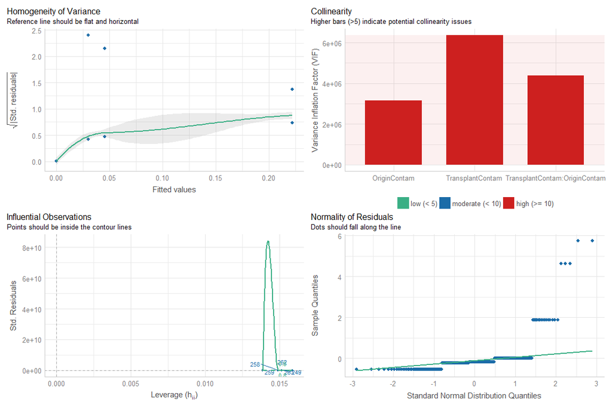

```r
mod4 <-
  glm(Death ~ (TransplantContam + OriginContam) ^ 2,
      data = dat2,
      family = "binomial")
performance::check_model(mod4)
```

```r
car::Anova(mod4, type = "3")
```

```
## Analysis of Deviance Table (Type III tests)
##
## Response: Death
##                               LR Chisq Df Pr(>Chisq)
## TransplantContam                2.6807  1    0.10157
## OriginContam                   21.9923  1  2.738e-06 ***
## TransplantContam:OriginContam   6.5915  1    0.01025 *
## ---
## Signif. codes:  0 '***' 0.001 '**' 0.01 '*' 0.05 '.' 0.1 ' ' 1
```

```r
summary(mod4)
```

```
##
## Call:
## glm(formula = Death ~ (TransplantContam + OriginContam)^2, family = "binomial",
##     data = dat2)
##
## Deviance Residuals:
##      Min        1Q    Median        3Q       Max
## -0.70896  -0.30502  -0.24619  -0.00008   2.65011
##
## Coefficients:
##                                   Estimate Std. Error z value Pr(>|z|)
## (Intercept)                         -19.57    1354.88  -0.014    0.988
## TransplantContamLC                   16.08    1354.88   0.012    0.991
## OriginContamLC                       18.31    1354.88   0.014    0.989
## TransplantContamLC:OriginContamLC   -17.88    1354.88  -0.013    0.989
##
## (Dispersion parameter for binomial family taken to be 1)
##
##     Null deviance: 147.26  on 267  degrees of freedom
## Residual deviance: 118.67  on 264  degrees of freedom
## AIC: 126.67
##
## Number of Fisher Scoring iterations: 18
```

```r
modSurvival <- mod4
```

Here the interaction between fish origin and the transplant site is significant. Alternatively, we can compute a survival rate per cage and build model with survival transformed to logit

### 5.1.2 Build model with survival transformed to logit

NB: here we used the CagingSite as random effect only since survival is computed for each cage so that there is no need to add the cageSiteID.

#### 5.1.2.1 Create a new dataset containing survival rate within each cage

```r
dat2$CageIDInj <- paste(dat2$CageID, dat2$Injection, sep = "_")
n = as.data.frame(dplyr::count(dat2, CageIDInj))
names(n)[1] <- "CageIDInj"
names(n)[2] <- "n"
alive <-
  as.data.frame(dplyr::count(dat2[dat2$Death == "0", ], CageIDInj))
dead <-
  as.data.frame(dplyr::count(dat2[dat2$Death == "1", ], CageIDInj))
DeathSum <- dplyr::left_join(alive, dead, by = "CageIDInj")
DeathSum$n.y[is.na(DeathSum$n.y)] <- 0
DeathSum <- dplyr::left_join(DeathSum, n, by = "CageIDInj")
names(DeathSum)[2] <- "alive"
names(DeathSum)[3] <- "dead"
DeathSum$survival <- DeathSum$alive / DeathSum$n
DeathSum <-  dplyr::left_join(DeathSum,
                              dat2[match(DeathSum$CageIDInj,  dat2$CageIDInj), c(
                                "CageIDInj",
                                "CageID",
                                "OriginSite",
                                "OriginContam",
                                "SitesPair",
                                "CageSiteID",
                                "CagingSite",
                                "TransplantContam",
                                "Injection",
                                "CxOxI",
                                "CxO2xI",
                                "CxO",
                                "O2xI"
                              )], by = "CageIDInj")
```

#### 5.1.2.2 Build the full model

```r
modfull <-
 lme4::lmer(
    car::logit(survival) ~ (TransplantContam + OriginContam + Injection) ^ 3 +
   (1 | CagingSite) + (1 | OriginSite),
    data = DeathSum,
    na.action = na.exclude
  )
car::Anova(modfull, type = "3")
```

```
## Analysis of Deviance Table (Type III Wald chisquare tests)
##
## Response: car::logit(survival)
##                                           Chisq Df Pr(>Chisq)
## (Intercept)                             78.0809  1  < 2.2e-16 ***
## TransplantContam                         0.6331  1   0.426220
## OriginContam                             8.6911  1   0.003198 **
## Injection                                0.0000  1   1.000000
## TransplantContam:OriginContam            4.8891  1   0.027026 *
## TransplantContam:Injection               0.3166  1   0.573688
## OriginContam:Injection                   0.1793  1   0.671964
## TransplantContam:OriginContam:Injection  0.1893  1   0.663535
## ---
## Signif. codes:  0 '***' 0.001 '**' 0.01 '*' 0.05 '.' 0.1 ' ' 1
```

```r
summary(modfull)
```

```
## Linear mixed model fit by REML ['lmerMod']
## Formula:
## car::logit(survival) ~ (TransplantContam + OriginContam + Injection)^3 +
##     (1 | CagingSite) + (1 | OriginSite)
##    Data: DeathSum
##
## REML criterion at convergence: 129.1
##
## Scaled residuals:
##     Min      1Q  Median      3Q     Max
## -2.2969 -0.1086  0.0000  0.4594  2.0478
##
## Random effects:
##  Groups     Name        Variance Std.Dev.
##  CagingSite (Intercept) 0.000    0.000
##  OriginSite (Intercept) 0.000    0.000
##  Residual               1.031    1.016
## Number of obs: 48, groups:  CagingSite, 4; OriginSite, 4
##
## Fixed effects:
##                                                  Estimate Std. Error t value
## (Intercept)                                     3.664e+00  4.146e-01   8.836
## TransplantContamLC                             -4.665e-01  5.863e-01  -0.796
## OriginContamLC                                 -1.729e+00  5.863e-01  -2.948
## InjectionPBS                                   -1.602e-15  5.863e-01   0.000
## TransplantContamLC:OriginContamLC               1.833e+00  8.292e-01   2.211
## TransplantContamLC:InjectionPBS                 4.665e-01  8.292e-01   0.563
## OriginContamLC:InjectionPBS                    -3.511e-01  8.292e-01  -0.423
## TransplantContamLC:OriginContamLC:InjectionPBS -5.102e-01  1.173e+00  -0.435
##
## Correlation of Fixed Effects:
##             (Intr) TrnCLC OrgCLC InjPBS TrCLC:OCLC TCLC:I OCLC:I
## TrnsplntCLC -0.707
## OrignCntmLC -0.707  0.500
## InjectinPBS -0.707  0.500  0.500
## TrnCLC:OCLC  0.500 -0.707 -0.707 -0.354
## TrnCLC:IPBS  0.500 -0.707 -0.354 -0.707  0.500
## OrgCLC:IPBS  0.500 -0.354 -0.707 -0.707  0.500      0.500
## TCLC:OCLC:I -0.354  0.500  0.500  0.500 -0.707     -0.707 -0.707
## optimizer (nloptwrap) convergence code: 0 (OK)
## boundary (singular) fit: see ?isSingular
```

#### 5.1.2.3 Refine the model

```r
mod2 <-
 lme4::lmer(
    car::logit(survival) ~ (TransplantContam + OriginContam + Injection) ^ 2+
   (1 | CagingSite) + (1 | OriginSite),
    data = DeathSum,
    na.action = na.exclude
  )
car::Anova(mod2, type="3")
```

```
## Analysis of Deviance Table (Type III Wald chisquare tests)
##
## Response: car::logit(survival)
##                                 Chisq Df Pr(>Chisq)
## (Intercept)                   87.8938  1  < 2.2e-16 ***
## TransplantContam               0.4547  1   0.500121
## OriginContam                  10.1418  1   0.001449 **
## Injection                      0.0644  1   0.799735
## TransplantContam:OriginContam  7.3930  1   0.006548 **
## TransplantContam:Injection     0.1327  1   0.715665
## OriginContam:Injection         1.0905  1   0.296361
## ---
## Signif. codes:  0 '***' 0.001 '**' 0.01 '*' 0.05 '.' 0.1 ' ' 1
```

```r
summary(mod2)
```

```
## Linear mixed model fit by REML ['lmerMod']
## Formula:
## car::logit(survival) ~ (TransplantContam + OriginContam + Injection)^2 +
##     (1 | CagingSite) + (1 | OriginSite)
##    Data: DeathSum
##
## REML criterion at convergence: 131.4
##
## Scaled residuals:
##      Min       1Q   Median       3Q      Max
## -2.38339 -0.17309  0.06342  0.42306  2.13179
##
## Random effects:
##  Groups     Name        Variance Std.Dev.
##  CagingSite (Intercept) 0.000    0.000
##  OriginSite (Intercept) 0.000    0.000
##  Residual               1.011    1.005
## Number of obs: 48, groups:  CagingSite, 4; OriginSite, 4
##
## Fixed effects:
##                                   Estimate Std. Error t value
## (Intercept)                         3.5998     0.3840   9.375
## TransplantContamLC                 -0.3390     0.5027  -0.674
## OriginContamLC                     -1.6010     0.5027  -3.185
## InjectionPBS                        0.1275     0.5027   0.254
## TransplantContamLC:OriginContamLC   1.5784     0.5805   2.719
## TransplantContamLC:InjectionPBS     0.2115     0.5805   0.364
## OriginContamLC:InjectionPBS        -0.6062     0.5805  -1.044
##
## Correlation of Fixed Effects:
##             (Intr) TrnCLC OrgCLC InjPBS TCLC:O TCLC:I
## TrnsplntCLC -0.655
## OrignCntmLC -0.655  0.333
## InjectinPBS -0.655  0.333  0.333
## TrnCLC:OCLC  0.378 -0.577 -0.577  0.000
## TrnCLC:IPBS  0.378 -0.577  0.000 -0.577  0.000
## OrgCLC:IPBS  0.378  0.000 -0.577 -0.577  0.000  0.000
## optimizer (nloptwrap) convergence code: 0 (OK)
## boundary (singular) fit: see ?isSingular
```

#### 5.1.2.4 Refine the model

```r
mod3 <-
 lme4::lmer(
    car::logit(survival) ~ (TransplantContam + OriginContam) ^ 2 + Injection +
   (1 | CagingSite) + (1 | OriginSite),
    data = DeathSum,
    na.action = na.exclude
  )
car::Anova(mod3, type = "3")
```

```
## Analysis of Deviance Table (Type III Wald chisquare tests)
##
## Response: car::logit(survival)
##                                  Chisq Df Pr(>Chisq)
## (Intercept)                   132.2805  1  < 2.2e-16 ***
## TransplantContam                0.3289  1   0.566321
## OriginContam                   21.9139  1  2.852e-06 ***
## Injection                       0.0590  1   0.808152
## TransplantContam:OriginContam   7.5290  1   0.006071 **
## ---
## Signif. codes:  0 '***' 0.001 '**' 0.01 '*' 0.05 '.' 0.1 ' ' 1
```

```r
summary(mod3)
```

```
## Linear mixed model fit by REML ['lmerMod']
## Formula: car::logit(survival) ~ (TransplantContam + OriginContam)^2 +
##     Injection + (1 | CagingSite) + (1 | OriginSite)
##    Data: DeathSum
##
## REML criterion at convergence: 134.1
##
## Scaled residuals:
##     Min      1Q  Median      3Q     Max
## -2.6104 -0.1017  0.1171  0.5260  1.9462
##
## Random effects:
##  Groups     Name        Variance Std.Dev.
##  CagingSite (Intercept) 0.0000   0.0000
##  OriginSite (Intercept) 0.0000   0.0000
##  Residual               0.9927   0.9963
## Number of obs: 48, groups:  CagingSite, 4; OriginSite, 4
##
## Fixed effects:
##                                   Estimate Std. Error t value
## (Intercept)                        3.69848    0.32157  11.501
## TransplantContamLC                -0.23327    0.40676  -0.573
## OriginContamLC                    -1.90412    0.40676  -4.681
## InjectionPBS                      -0.06984    0.28762  -0.243
## TransplantContamLC:OriginContamLC  1.57841    0.57524   2.744
##
## Correlation of Fixed Effects:
##             (Intr) TrnCLC OrgCLC InjPBS
## TrnsplntCLC -0.632
## OrignCntmLC -0.632  0.500
## InjectinPBS -0.447  0.000  0.000
## TrnCLC:OCLC  0.447 -0.707 -0.707  0.000
## optimizer (nloptwrap) convergence code: 0 (OK)
## boundary (singular) fit: see ?isSingular
```

#### 5.1.2.5 Refine the model

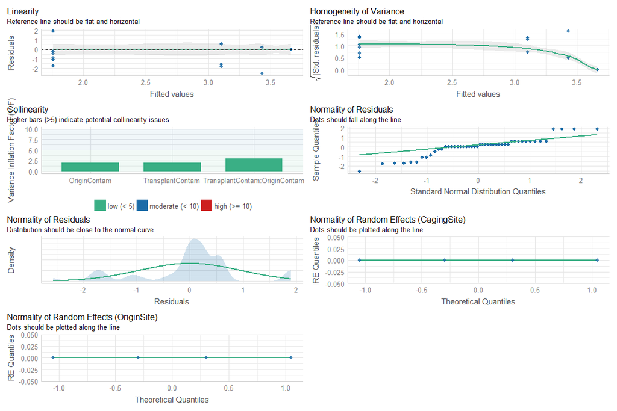

```r
mod4 <-
 lme4::lmer(
    car::logit(survival) ~ (TransplantContam + OriginContam) ^ 2 +
   (1 | CagingSite) + (1 | OriginSite),
    data = DeathSum,
    na.action = na.exclude
  )
performance::check_model(mod4)
```

```r
car::Anova(mod4, type = "3")
```

```
## Analysis of Deviance Table (Type III Wald chisquare tests)
##
## Response: car::logit(survival)
##                                  Chisq Df Pr(>Chisq)
## (Intercept)                   165.7888  1  < 2.2e-16 ***
## TransplantContam                0.3361  1   0.562109
## OriginContam                   22.3928  1  2.222e-06 ***
## TransplantContam:OriginContam   7.6935  1   0.005542 **
## ---
## Signif. codes:  0 '***' 0.001 '**' 0.01 '*' 0.05 '.' 0.1 ' ' 1
```

```r
summary(mod4)
```

```
## Linear mixed model fit by REML ['lmerMod']
## Formula: car::logit(survival) ~ (TransplantContam + OriginContam)^2 +
##     (1 | CagingSite) + (1 | OriginSite)
##    Data: DeathSum
##
## REML criterion at convergence: 133.5
##
## Scaled residuals:
##      Min       1Q   Median       3Q      Max
## -2.60333 -0.06735  0.11833  0.56713  1.93187
##
## Random effects:
##  Groups     Name        Variance Std.Dev.
##  CagingSite (Intercept) 0.0000   0.0000
##  OriginSite (Intercept) 0.0000   0.0000
##  Residual               0.9715   0.9856
## Number of obs: 48, groups:  CagingSite, 4; OriginSite, 4
##
## Fixed effects:
##                                   Estimate Std. Error t value
## (Intercept)                         3.6636     0.2845  12.876
## TransplantContamLC                 -0.2333     0.4024  -0.580
## OriginContamLC                     -1.9041     0.4024  -4.732
## TransplantContamLC:OriginContamLC   1.5784     0.5691   2.774
##
## Correlation of Fixed Effects:
##             (Intr) TrnCLC OrgCLC
## TrnsplntCLC -0.707
## OrignCntmLC -0.707  0.500
## TrnCLC:OCLC  0.500 -0.707 -0.707
## optimizer (nloptwrap) convergence code: 0 (OK)
## boundary (singular) fit: see ?isSingular
```

Although, this last method also result in singular fit (“CagingSite” and “OriginSite” random effects variance is estimated as zero), here the interaction between fish origin and the transplant site is significant. Both simplified methods give similar results, hence the results of the more straightforward method (glm) are reported in the statistic table (table 3). Also, because an interaction is significant, perform a posthoc test.

### 5.1.3 Posthoc test (test for equality of proportions)

```r
# create two matrix containing fish survival rate according to their origin and transplant sites
DeathSum$CxO2 = paste(DeathSum$TransplantContam, DeathSum$OriginContam, sep =
                        "_")
a = aggregate(DeathSum$alive, list(DeathSum$CxO2), sum)
b = aggregate(DeathSum$dead, list(DeathSum$CxO2), sum)

# create the matrix for Low contamination origin
OriginLC = matrix(
  c(b[b$Group.1 == "LC_LC", 2], a[a$Group.1 == "LC_LC", 2], b[b$Group.1 == "HC_LC", 2], a[a$Group.1 == "HC_LC", 2]),
  nrow = 2,
  ncol = 2,
  dimnames = list(c("Dead", "Alive"), c("LC", "HC"))
)
OriginLC
```

```
##       LC HC
## Dead   3 16
## Alive 63 56
```

```r
# create the matrix for High contamination origin
OriginHC = matrix(
  c(b[b$Group.1 == "LC_HC", 2], a[a$Group.1 == "LC_HC", 2], b[b$Group.1 == "HC_HC", 2], a[a$Group.1 == "HC_HC", 2]),
  nrow = 2,
  ncol = 2,
  dimnames = list(c("Dead", "Alive"), c("LC", "HC"))
)
OriginHC
```

```
##       LC HC
## Dead   2  0
## Alive 65 63
```

```r
# run test for equality of proportions on each matrix
fisher.test(OriginLC, conf.level = 0.95)
```

```
##
##  Fisher's Exact Test for Count Data
##
## data:  OriginLC
## p-value = 0.002728
## alternative hypothesis: true odds ratio is not equal to 1
## 95 percent confidence interval:
##  0.02990582 0.63312320
## sample estimates:
## odds ratio
##  0.1685805
```

```r
fisher.test(OriginHC, conf.level = 0.95)
```

```
##
##  Fisher's Exact Test for Count Data
##
## data:  OriginHC
## p-value = 0.4966
## alternative hypothesis: true odds ratio is not equal to 1
## 95 percent confidence interval:
##  0.1769481       Inf
## sample estimates:
## odds ratio
##        Inf
```

Here fish from Low Contamination, display a significant decrease in survival when exposed to High Contamination site. On the contrary, fish from High contamination site do not display a significant change in survival according to transplant site.

Also,because interaction between the contamination in origin and transplant site of fish is significant We test for parallel response between replicate populations.

### 5.1.4 Test for parallel responses between replicate populations (from the same origin)

#### 5.1.4.1 For Populations from High contamination sites (AUSCOR and RIOU)

```r
dat3 <- dat2[which(dat2$OriginSite %in% c("AUSCOR", "RIOU")),]
## build the null model
mod.null <-
  glm(Death ~ TransplantContam + OriginSite,
      data = dat3)
## build the model with the site of origin in interaction with the level of contamination in transplant sites
mod.par <-
  glm(Death ~ TransplantContam * OriginSite,
      data = dat3)

anova(mod.null, mod.par, test = "LRT")
```

```
## Analysis of Deviance Table
##
## Model 1: Death ~ TransplantContam + OriginSite
## Model 2: Death ~ TransplantContam * OriginSite
##   Resid. Df Resid. Dev Df Deviance Pr(>Chi)
## 1       127     1.9121
## 2       126     1.8857  1 0.026394   0.1842
```

```r
coef(mod.par)
```

```
##                       (Intercept)                TransplantContamLC
##                      5.355515e-17                      5.714286e-02
##                    OriginSiteRIOU TransplantContamLC:OriginSiteRIOU
##                     -4.878627e-18                     -5.714286e-02
```

```r
summary(mod.par)
```

```
##
## Call:
## glm(formula = Death ~ TransplantContam * OriginSite, data = dat3)
##
## Deviance Residuals:
##      Min        1Q    Median        3Q       Max
## -0.05714  -0.04286   0.00000   0.00000   0.94286
##
## Coefficients:
##                                     Estimate Std. Error t value Pr(>|t|)
## (Intercept)                        5.356e-17  2.272e-02   0.000   1.0000
## TransplantContamLC                 5.714e-02  3.072e-02   1.860   0.0652 .
## OriginSiteRIOU                    -4.879e-18  3.092e-02   0.000   1.0000
## TransplantContamLC:OriginSiteRIOU -5.714e-02  4.303e-02  -1.328   0.1866
## ---
## Signif. codes:  0 '***' 0.001 '**' 0.01 '*' 0.05 '.' 0.1 ' ' 1
##
## (Dispersion parameter for gaussian family taken to be 0.01496599)
##
##     Null deviance: 1.9692  on 129  degrees of freedom
## Residual deviance: 1.8857  on 126  degrees of freedom
## AIC: -171.4
##
## Number of Fisher Scoring iterations: 2
```

The null model and the model including the site of origin in interaction with the level of contaminant in transplant sites are not significantly different, we hence cannot reject the null hypothesis: the slopes of HC populations are parallel.

#### 5.1.4.2 For Populations from Low contamination sites (ARIMAS and CELFIG)

```r
dat4 <- dat2[which(dat2$OriginSite %in% c("ARIMAS", "CELFIG")),]
## build the null model
mod.null <-
  glm(Death ~ TransplantContam + OriginSite,
      data = dat4)
## build the model with the site of origin in interaction with the level of contamination in transplant sites
mod.par <-
  glm(Death ~ TransplantContam * OriginSite,
      data = dat4)

anova(mod.null, mod.par, test = "LRT")
```

```
## Analysis of Deviance Table
##
## Model 1: Death ~ TransplantContam + OriginSite
## Model 2: Death ~ TransplantContam * OriginSite
##   Resid. Df Resid. Dev Df Deviance Pr(>Chi)
## 1       135     15.308
## 2       134     15.276  1 0.032262   0.5947
```

```r
coef(mod.par)
```

```
##                         (Intercept)                  TransplantContamLC
##                          0.23684211                         -0.20653907
##                    OriginSiteCELFIG TransplantContamLC:OriginSiteCELFIG
##                         -0.03095975                          0.06126278
```

```r
summary(mod.par)
```

```
##
## Call:
## glm(formula = Death ~ TransplantContam * OriginSite, data = dat4)
##
## Deviance Residuals:
##      Min        1Q    Median        3Q       Max
## -0.23684  -0.20588  -0.06061  -0.03030   0.96970
##
## Coefficients:
##                                     Estimate Std. Error t value Pr(>|t|)
## (Intercept)                          0.23684    0.05477   4.324 2.97e-05 ***
## TransplantContamLC                  -0.20654    0.08034  -2.571   0.0112 *
## OriginSiteCELFIG                    -0.03096    0.07970  -0.388   0.6983
## TransplantContamLC:OriginSiteCELFIG  0.06126    0.11516   0.532   0.5956
## ---
## Signif. codes:  0 '***' 0.001 '**' 0.01 '*' 0.05 '.' 0.1 ' ' 1
##
## (Dispersion parameter for gaussian family taken to be 0.113998)
##
##     Null deviance: 16.384  on 137  degrees of freedom
## Residual deviance: 15.276  on 134  degrees of freedom
## AIC: 97.891
##
## Number of Fisher Scoring iterations: 2
```

The null model and the model including the site of origin in interaction with the level of contaminant in transplant sites are not significantly different, we hence cannot reject the null hypothesis: the slopes of LC populations are parallel.

### 5.1.5 Visualize

The plot reported below correspond to the figure 2A from the manuscript

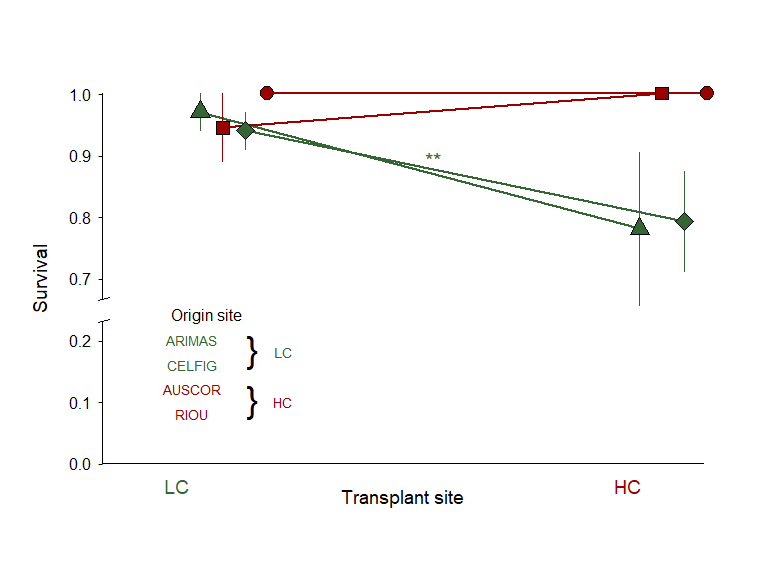

```r
par(mfrow=c(1,1))
Survivplot()
```

## 5.2 Metal bioaccumulation

### 5.2.1 Create a global index of metal accumulation: Zn, Cd, Cu

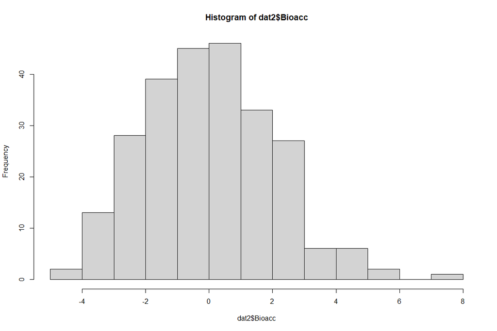

```r
dat2 = dat1[is.na(dat1$MuscleCd) == F, ]
dat2$Cdscaled = scale(log(dat2$MuscleCd), center = T, scale = T)
dat2$Cuscaled = scale(log(dat2$MuscleCu), center = T, scale = T)
dat2$Znscaled = scale(log(dat2$MuscleZn), center = T, scale = T)
dat2$Bioacc = dat2$Cdscaled + dat2$Cuscaled + dat2$Znscaled
hist(dat2$Bioacc)
```

### 5.2.2 Visualize

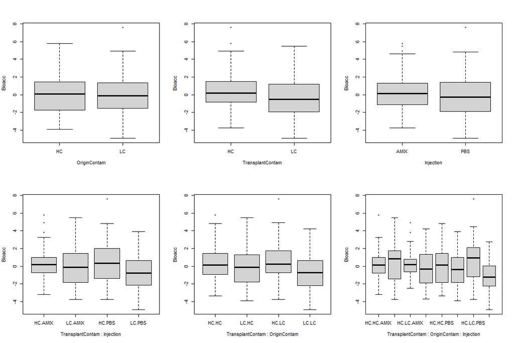

```r
par(mfrow=c(2,3))
boxplot(Bioacc ~ OriginContam, data = dat2)
boxplot(Bioacc ~ TransplantContam, data = dat2)
boxplot(Bioacc ~ Injection, data = dat2)
boxplot(Bioacc ~ TransplantContam * Injection, data = dat2)
boxplot(Bioacc ~ TransplantContam * OriginContam, data = dat2)
boxplot(Bioacc ~ TransplantContam * OriginContam * Injection, data = dat2)
```

### 5.2.3 Build the full model

```r
modfull <-
 lme4::lmer(
    Bioacc ~ (TransplantContam + OriginContam + Injection) ^ 3 +  SizeEnd +
      (1 | CagingSite /  CageSiteID) + (1| OriginSite),
    data = dat2,
    na.action = na.exclude
  )
car::Anova(modfull, type = "3")
```

```
## Analysis of Deviance Table (Type III Wald chisquare tests)
##
## Response: Bioacc
##                                          Chisq Df Pr(>Chisq)
## (Intercept)                             0.2687  1     0.6042
## TransplantContam                        0.0320  1     0.8580
## OriginContam                            0.7147  1     0.3979
## Injection                               0.0171  1     0.8961
## SizeEnd                                 0.8024  1     0.3704
## TransplantContam:OriginContam           1.5238  1     0.2170
## TransplantContam:Injection              1.1853  1     0.2763
## OriginContam:Injection                  0.1581  1     0.6909
## TransplantContam:OriginContam:Injection 0.4158  1     0.5191
```

```r
summary(modfull)
```

```
## Linear mixed model fit by REML ['lmerMod']
## Formula: Bioacc ~ (TransplantContam + OriginContam + Injection)^3 + SizeEnd +
##     (1 | CagingSite/CageSiteID) + (1 | OriginSite)
##    Data: dat2
##
## REML criterion at convergence: 998.1
##
## Scaled residuals:
##     Min      1Q  Median      3Q     Max
## -2.5929 -0.6166  0.0019  0.6315  3.6126
##
## Random effects:
##  Groups                Name        Variance Std.Dev.
##  CageSiteID:CagingSite (Intercept) 0.06108  0.2471
##  CagingSite            (Intercept) 1.62483  1.2747
##  OriginSite            (Intercept) 0.00000  0.0000
##  Residual                          3.17253  1.7812
## Number of obs: 248, groups:
## CageSiteID:CagingSite, 24; CagingSite, 4; OriginSite, 4
##
## Fixed effects:
##                                                Estimate Std. Error t value
## (Intercept)                                    -0.64621    1.24654  -0.518
## TransplantContamLC                              0.24267    1.35588   0.179
## OriginContamLC                                  0.39650    0.46902   0.845
## InjectionPBS                                    0.05873    0.44959   0.131
## SizeEnd                                         0.07050    0.07871   0.896
## TransplantContamLC:OriginContamLC              -0.80902    0.65538  -1.234
## TransplantContamLC:InjectionPBS                -0.68677    0.63080  -1.089
## OriginContamLC:InjectionPBS                     0.25975    0.65322   0.398
## TransplantContamLC:OriginContamLC:InjectionPBS -0.58575    0.90841  -0.645
##
## Correlation of Fixed Effects:
##             (Intr) TrnCLC OrgCLC InjPBS SizEnd TrCLC:OCLC TCLC:I OCLC:I
## TrnsplntCLC -0.554
## OrignCntmLC -0.212  0.169
## InjectinPBS -0.180  0.158  0.457
## SizeEnd     -0.639  0.017  0.047  0.013
## TrnCLC:OCLC  0.123 -0.240 -0.714 -0.326  0.013
## TrnCLC:IPBS  0.117 -0.225 -0.325 -0.712  0.008  0.466
## OrgCLC:IPBS  0.125 -0.109 -0.648 -0.688 -0.011  0.463      0.490
## TCLC:OCLC:I -0.081  0.156  0.466  0.495 -0.006 -0.652     -0.694 -0.719
## optimizer (nloptwrap) convergence code: 0 (OK)
## boundary (singular) fit: see ?isSingular
```

### 5.2.4 Refining the model

```r
mod2 <-
 lme4::lmer(
    Bioacc ~ (TransplantContam + OriginContam + Injection) ^ 2  +  SizeEnd+
      (1 | CagingSite /  CageSiteID) + (1| OriginSite),
    data = dat2,
    na.action = na.exclude
  )
car::Anova(mod2, type = "3")
```

```
## Analysis of Deviance Table (Type III Wald chisquare tests)
##
## Response: Bioacc
##                                Chisq Df Pr(>Chisq)
## (Intercept)                   0.3280  1    0.56683
## TransplantContam              0.0802  1    0.77698
## OriginContam                  1.6806  1    0.19484
## Injection                     0.2684  1    0.60444
## SizeEnd                       0.7970  1    0.37199
## TransplantContam:OriginContam 4.7839  1    0.02873 *
## TransplantContam:Injection    4.5674  1    0.03259 *
## OriginContam:Injection        0.0090  1    0.92439
## ---
## Signif. codes:  0 '***' 0.001 '**' 0.01 '*' 0.05 '.' 0.1 ' ' 1
```

```r
summary(mod2)
```

```
## Linear mixed model fit by REML ['lmerMod']
## Formula: Bioacc ~ (TransplantContam + OriginContam + Injection)^2 + SizeEnd +
##     (1 | CagingSite/CageSiteID) + (1 | OriginSite)
##    Data: dat2
##
## REML criterion at convergence: 1000.2
##
## Scaled residuals:
##     Min      1Q  Median      3Q     Max
## -2.6406 -0.6315 -0.0083  0.6140  3.6553
##
## Random effects:
##  Groups                Name        Variance  Std.Dev.
##  CageSiteID:CagingSite (Intercept) 6.007e-02 2.451e-01
##  CagingSite            (Intercept) 1.622e+00 1.274e+00
##  OriginSite            (Intercept) 1.265e-09 3.557e-05
##  Residual                          3.165e+00 1.779e+00
## Number of obs: 248, groups:
## CageSiteID:CagingSite, 24; CagingSite, 4; OriginSite, 4
##
## Fixed effects:
##                                   Estimate Std. Error t value
## (Intercept)                       -0.71077    1.24102  -0.573
## TransplantContamLC                 0.37903    1.33812   0.283
## OriginContamLC                     0.53707    0.41428   1.296
## InjectionPBS                       0.20217    0.39028   0.518
## SizeEnd                            0.07015    0.07858   0.893
## TransplantContamLC:OriginContamLC -1.08431    0.49575  -2.187
## TransplantContamLC:InjectionPBS   -0.96917    0.45349  -2.137
## OriginContamLC:InjectionPBS       -0.04305    0.45353  -0.095
##
## Correlation of Fixed Effects:
##             (Intr) TrnCLC OrgCLC InjPBS SizEnd TCLC:O TCLC:I
## TrnsplntCLC -0.550
## OrignCntmLC -0.198  0.110
## InjectinPBS -0.162  0.094  0.295
## SizeEnd     -0.641  0.018  0.056  0.019
## TrnCLC:OCLC  0.092 -0.184 -0.611 -0.006  0.011
## TrnCLC:IPBS  0.085 -0.164 -0.003 -0.590  0.005  0.024
## OrgCLC:IPBS  0.097  0.005 -0.510 -0.551 -0.023 -0.010 -0.018
## optimizer (nloptwrap) convergence code: 0 (OK)
## boundary (singular) fit: see ?isSingular
```

### 5.2.5 Refining the model

```r
mod3 <-
 lme4::lmer(
    Bioacc ~ (TransplantContam + OriginContam) ^ 2 + (TransplantContam + Injection) ^ 2 + SizeEnd +
      (1 | CagingSite /  CageSiteID) + (1| OriginSite),
    data = dat2,
    na.action = na.exclude
  )
car::Anova(mod3, type = "3")
```

```
## Analysis of Deviance Table (Type III Wald chisquare tests)
##
## Response: Bioacc
##                                Chisq Df Pr(>Chisq)
## (Intercept)                   0.3213  1    0.57080
## TransplantContam              0.0806  1    0.77648
## OriginContam                  2.1094  1    0.14639
## Injection                     0.3124  1    0.57618
## SizeEnd                       0.7964  1    0.37217
## TransplantContam:OriginContam 4.7930  1    0.02858 *
## TransplantContam:Injection    4.5959  1    0.03205 *
## ---
## Signif. codes:  0 '***' 0.001 '**' 0.01 '*' 0.05 '.' 0.1 ' ' 1
```

```r
summary(mod3)
```

```
## Linear mixed model fit by REML ['lmerMod']
## Formula: Bioacc ~ (TransplantContam + OriginContam)^2 + (TransplantContam +
##     Injection)^2 + SizeEnd + (1 | CagingSite/CageSiteID) + (1 |
##     OriginSite)
##    Data: dat2
##
## REML criterion at convergence: 1000.4
##
## Scaled residuals:
##     Min      1Q  Median      3Q     Max
## -2.6527 -0.6343 -0.0135  0.6174  3.6569
##
## Random effects:
##  Groups                Name        Variance Std.Dev.
##  CageSiteID:CagingSite (Intercept) 0.06142  0.2478
##  CagingSite            (Intercept) 1.62265  1.2738
##  OriginSite            (Intercept) 0.00000  0.0000
##  Residual                          3.15118  1.7752
## Number of obs: 248, groups:
## CageSiteID:CagingSite, 24; CagingSite, 4; OriginSite, 4
##
## Fixed effects:
##                                   Estimate Std. Error t value
## (Intercept)                       -0.69980    1.23449  -0.567
## TransplantContamLC                 0.37990    1.33810   0.284
## OriginContamLC                     0.51742    0.35625   1.452
## InjectionPBS                       0.18171    0.32508   0.559
## SizeEnd                            0.07001    0.07845   0.892
## TransplantContamLC:OriginContamLC -1.08527    0.49572  -2.189
## TransplantContamLC:InjectionPBS   -0.96988    0.45241  -2.144
##
## Correlation of Fixed Effects:
##             (Intr) TrnCLC OrgCLC InjPBS SizEnd TCLC:O
## TrnsplntCLC -0.554
## OrignCntmLC -0.173  0.130
## InjectinPBS -0.130  0.116  0.019
## SizeEnd     -0.642  0.018  0.051  0.007
## TrnCLC:OCLC  0.094 -0.184 -0.716 -0.014  0.011
## TrnCLC:IPBS  0.087 -0.163 -0.013 -0.718  0.005  0.024
## optimizer (nloptwrap) convergence code: 0 (OK)
## boundary (singular) fit: see ?isSingular
```

### 5.2.6 Refining the model

```r
mod4 <-
 lme4::lmer(
    Bioacc ~ (TransplantContam + OriginContam) ^ 2 + (TransplantContam + Injection) ^ 2 +
      (1 | CagingSite /  CageSiteID) + (1| OriginSite),
    data = dat2,
    na.action = na.exclude
  )
car::Anova(mod4, type = "3")
```

```
## Analysis of Deviance Table (Type III Wald chisquare tests)
##
## Response: Bioacc
##                                Chisq Df Pr(>Chisq)
## (Intercept)                   0.0001  1    0.99345
## TransplantContam              0.0699  1    0.79149
## OriginContam                  2.0077  1    0.15650
## Injection                     0.3065  1    0.57987
## TransplantContam:OriginContam 4.9131  1    0.02665 *
## TransplantContam:Injection    4.6157  1    0.03168 *
## ---
## Signif. codes:  0 '***' 0.001 '**' 0.01 '*' 0.05 '.' 0.1 ' ' 1
```

```r
summary(mod4)
```

```
## Linear mixed model fit by REML ['lmerMod']
## Formula: Bioacc ~ (TransplantContam + OriginContam)^2 + (TransplantContam +
##     Injection)^2 + (1 | CagingSite/CageSiteID) + (1 | OriginSite)
##    Data: dat2
##
## REML criterion at convergence: 998
##
## Scaled residuals:
##     Min      1Q  Median      3Q     Max
## -2.7307 -0.6338  0.0011  0.6105  3.6689
##
## Random effects:
##  Groups                Name        Variance Std.Dev.
##  CageSiteID:CagingSite (Intercept) 0.05418  0.2328
##  CagingSite            (Intercept) 1.66493  1.2903
##  OriginSite            (Intercept) 0.00000  0.0000
##  Residual                          3.15254  1.7755
## Number of obs: 248, groups:
## CageSiteID:CagingSite, 24; CagingSite, 4; OriginSite, 4
##
## Fixed effects:
##                                    Estimate Std. Error t value
## (Intercept)                        0.007861   0.957003   0.008
## TransplantContamLC                 0.357625   1.352719   0.264
## OriginContamLC                     0.499324   0.352393   1.417
## InjectionPBS                       0.179984   0.325128   0.554
## TransplantContamLC:OriginContamLC -1.087981   0.490846  -2.217
## TransplantContamLC:InjectionPBS   -0.972115   0.452478  -2.148
##
## Correlation of Fixed Effects:
##             (Intr) TrnCLC OrgCLC InjPBS TCLC:O
## TrnsplntCLC -0.707
## OrignCntmLC -0.180  0.127
## InjectinPBS -0.162  0.114  0.019
## TrnCLC:OCLC  0.129 -0.180 -0.718 -0.014
## TrnCLC:IPBS  0.116 -0.162 -0.014 -0.719  0.024
## optimizer (nloptwrap) convergence code: 0 (OK)
## boundary (singular) fit: see ?isSingular
```

```r
modBioacc <- mod4
RmodBioacc <- MuMIn::r.squaredGLMM(modBioacc)
```

Now that we have identified the best model, add sex as covariate to check whether results are sensitive NB: sample size is reduced when adding sex variable within the model, for this reason the sex effect on results is checked on the final model

### 5.2.7 Test for the sex effect

```r
dat2 = dat2[is.na(dat2$Sex) == F, ]
 modSex <-
 lme4::lmer(
    Bioacc ~ (TransplantContam + OriginContam) ^ 2 + (TransplantContam + Injection) ^ 2 + Sex +
      (1 | CagingSite /  CageSiteID) + (1| OriginSite),
    data = dat2,
    na.action = na.exclude
  )
car::Anova(modSex, type = "3")
```

```
## Analysis of Deviance Table (Type III Wald chisquare tests)
##
## Response: Bioacc
##                                Chisq Df Pr(>Chisq)
## (Intercept)                   0.0049  1    0.94411
## TransplantContam              0.0543  1    0.81582
## OriginContam                  1.9330  1    0.16443
## Injection                     0.2676  1    0.60495
## Sex                           0.9997  1    0.31737
## TransplantContam:OriginContam 4.3526  1    0.03695 *
## TransplantContam:Injection    4.2714  1    0.03876 *
## ---
## Signif. codes:  0 '***' 0.001 '**' 0.01 '*' 0.05 '.' 0.1 ' ' 1
```

```r
summary(modSex)
```

```
## Linear mixed model fit by REML ['lmerMod']
## Formula: Bioacc ~ (TransplantContam + OriginContam)^2 + (TransplantContam +
##     Injection)^2 + Sex + (1 | CagingSite/CageSiteID) + (1 | OriginSite)
##    Data: dat2
##
## REML criterion at convergence: 994.4
##
## Scaled residuals:
##     Min      1Q  Median      3Q     Max
## -2.8057 -0.6443  0.0424  0.5911  3.5562
##
## Random effects:
##  Groups                Name        Variance Std.Dev.
##  CageSiteID:CagingSite (Intercept) 0.08238  0.287
##  CagingSite            (Intercept) 1.61475  1.271
##  OriginSite            (Intercept) 0.00000  0.000
##  Residual                          3.14100  1.772
## Number of obs: 247, groups:
## CageSiteID:CagingSite, 24; CagingSite, 4; OriginSite, 4
##
## Fixed effects:
##                                   Estimate Std. Error t value
## (Intercept)                        -0.0666     0.9500  -0.070
## TransplantContamLC                  0.3116     1.3380   0.233
## OriginContamLC                      0.5101     0.3669   1.390
## InjectionPBS                        0.1686     0.3260   0.517
## SexM                                0.2379     0.2379   1.000
## TransplantContamLC:OriginContamLC  -1.0691     0.5124  -2.086
## TransplantContamLC:InjectionPBS    -0.9358     0.4528  -2.067
##
## Correlation of Fixed Effects:
##             (Intr) TrnCLC OrgCLC InjPBS SexM   TCLC:O
## TrnsplntCLC -0.702
## OrignCntmLC -0.181  0.133
## InjectinPBS -0.166  0.115  0.009
## SexM        -0.088 -0.029 -0.053  0.037
## TrnCLC:OCLC  0.124 -0.190 -0.719 -0.004  0.099
## TrnCLC:IPBS  0.115 -0.164 -0.010 -0.718  0.030  0.022
## optimizer (nloptwrap) convergence code: 0 (OK)
## boundary (singular) fit: see ?isSingular
```

Adding the sex as covariate does no change the significance of the interactions, also sex effect is non-significant. The mod4 is thus the best model.

### 5.2.8 Posthoc test (pairwise t-test)

The interactions between fish origin and the transplant as well as between transplant and injection treatments are significant. Hence, perform posthoc test (pairwise t-test) according to significant interactions

```r
pairwise.t.test(dat2$Bioacc, dat2$CxI, p.adjust.method = "fdr")
```

```
##
##  Pairwise comparisons using t tests with pooled SD
##
## data:  dat2$Bioacc and dat2$CxI
##
##         HC_AMIX HC_PBS LC_AMIX
## HC_PBS  0.749   -      -
## LC_AMIX 0.640   0.530  -
## LC_PBS  0.012   0.011  0.040
##
## P value adjustment method: fdr
```

Here, fish from low contamination site and injected with a saline control solution, has bioaccumulated significantly less metals than the fish exposed to other treatment, even compared to LC exposed in Low contamination site and injected to the antigen mixture, suggesting that the antigen mixture could affect bioaccumulation in fish muscle.

```r
pairwise.t.test(dat2$Bioacc, dat2$CxO2, p.adjust.method = "fdr")
```

```
##
##  Pairwise comparisons using t tests with pooled SD
##
## data:  dat2$Bioacc and dat2$CxO2
##
##       HC_HC HC_LC LC_HC
## HC_LC 0.32  -     -
## LC_HC 0.57  0.18  -
## LC_LC 0.11  0.01  0.18
##
## P value adjustment method: fdr
```

Here fish from Low Contamination, display a significant increase in the amount of metal bioaccumulated in their muscle when exposed to High Contamination site compared to when they are exposed in low contamination site. On the contrary, the metal levels is constant in HC fish, whatever the site of transplantation.

Also,because interaction between the contamination in origin and transplant site of fish is significant We test for parallel response between replicate populations.

### 5.2.9 Test for parallel responses between replicate populations (from the same origin)

#### 5.2.9.1 For Populations from High contamination sites (AUSCOR and RIOU)

```r
dat3 <- dat2[which(dat2$OriginSite %in% c("AUSCOR", "RIOU")),]
## build the null model
mod.null <-
  glm(Bioacc ~ TransplantContam + OriginSite,
      data = dat3)
## build the model with the site of origin in interaction with the level of contam in transplant sites
mod.par <-
  glm(Bioacc ~ TransplantContam * OriginSite,
      data = dat3)

anova(mod.null, mod.par, test = "LRT")
```

```
## Analysis of Deviance Table
##
## Model 1: Bioacc ~ TransplantContam + OriginSite
## Model 2: Bioacc ~ TransplantContam * OriginSite
##   Resid. Df Resid. Dev Df Deviance Pr(>Chi)
## 1       125     405.31
## 2       124     393.62  1   11.688  0.05501 .
## ---
## Signif. codes:  0 '***' 0.001 '**' 0.01 '*' 0.05 '.' 0.1 ' ' 1
```

```r
coef(mod.par)
```

```
##                       (Intercept)                TransplantContamLC
##                        -0.5641966                        -0.7376128
##                    OriginSiteRIOU TransplantContamLC:OriginSiteRIOU
##                         1.3456317                         1.2108581
```

```r
summary(mod.par)
```

```
##
## Call:
## glm(formula = Bioacc ~ TransplantContam * OriginSite, data = dat3)
##
## Deviance Residuals:
##     Min       1Q   Median       3Q      Max
## -3.9865  -0.8885   0.0204   0.9680   6.3792
##
## Coefficients:
##                                   Estimate Std. Error t value Pr(>|t|)
## (Intercept)                        -0.5642     0.3308  -1.705  0.09064 .
## TransplantContamLC                 -0.7376     0.4535  -1.627  0.10638
## OriginSiteRIOU                      1.3456     0.4504   2.988  0.00339 **
## TransplantContamLC:OriginSiteRIOU   1.2109     0.6310   1.919  0.05731 .
## ---
## Signif. codes:  0 '***' 0.001 '**' 0.01 '*' 0.05 '.' 0.1 ' ' 1
##
## (Dispersion parameter for gaussian family taken to be 3.174371)
##
##     Null deviance: 529.49  on 127  degrees of freedom
## Residual deviance: 393.62  on 124  degrees of freedom
## AIC: 517.04
##
## Number of Fisher Scoring iterations: 2
```

The null model and the model including the site of origin in interaction with the level of contaminant in transplant sites are not significantly different, we hence cannot reject the null hypothesis: the slopes of HC populations are parallel.

#### 5.2.9.2 For Populations from Low contamination sites (ARIMAS and CELFIG)

```r
# We test for parallel response between replicate LC populations (ARIMAS and CELFIG)
dat4 <- dat2[which(dat2$OriginSite %in% c("ARIMAS", "CELFIG")),]
## build the null model
mod.null <-
  glm(Bioacc ~ TransplantContam + OriginSite,
      data = dat4)
## build the model with the site of origin in interaction with the level of contam in transplant sites
mod.par <-
  glm(Bioacc ~ TransplantContam * OriginSite,
      data = dat4)

anova(mod.null, mod.par, test = "LRT")
```

```
## Analysis of Deviance Table
##
## Model 1: Bioacc ~ TransplantContam + OriginSite
## Model 2: Bioacc ~ TransplantContam * OriginSite
##   Resid. Df Resid. Dev Df Deviance Pr(>Chi)
## 1       116     382.81
## 2       115     382.09  1  0.72023   0.6415
```

```r
coef(mod.par)
```

```
##                         (Intercept)                  TransplantContamLC
##                          -0.3383157                          -1.0450200
##                    OriginSiteCELFIG TransplantContamLC:OriginSiteCELFIG
##                           1.8961427                          -0.3118520
```

```r
summary(mod.par)
```

```
##
## Call:
## glm(formula = Bioacc ~ TransplantContam * OriginSite, data = dat4)
##
## Deviance Residuals:
##     Min       1Q   Median       3Q      Max
## -5.1336  -1.1292  -0.1314   1.1556   6.0411
##
## Coefficients:
##                                     Estimate Std. Error t value Pr(>|t|)
## (Intercept)                          -0.3383     0.3385  -1.000 0.319645
## TransplantContamLC                   -1.0450     0.4673  -2.236 0.027271 *
## OriginSiteCELFIG                      1.8961     0.4875   3.890 0.000168 ***
## TransplantContamLC:OriginSiteCELFIG  -0.3119     0.6698  -0.466 0.642389
## ---
## Signif. codes:  0 '***' 0.001 '**' 0.01 '*' 0.05 '.' 0.1 ' ' 1
##
## (Dispersion parameter for gaussian family taken to be 3.322503)
##
##     Null deviance: 513.14  on 118  degrees of freedom
## Residual deviance: 382.09  on 115  degrees of freedom
## AIC: 486.52
##
## Number of Fisher Scoring iterations: 2
```

The null model and the model including the site of origin in interaction with the level of contaminant in transplant sites are not significantly different, we hence cannot reject the null hypothesis: the slopes of LC populations are parallel.

### 5.2.10 Visualize

The plot reported below correspond to the figure 3 and the figure 2B from the manuscript

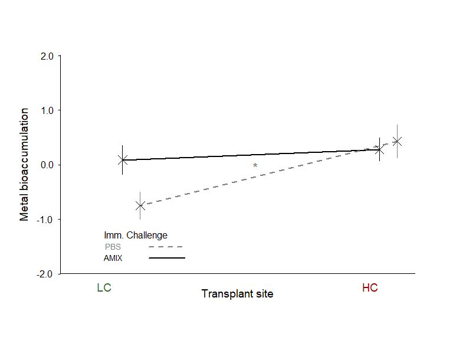

```r
BioaccPlot3()
```

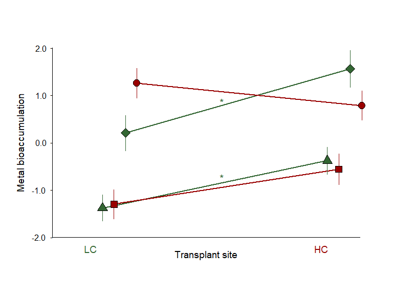

```r
BioaccPlot1()
```

## 5.3 Oxidative Stress Index

### 5.3.1 Create a global index of oxidative stress (Costantini and Dell’Omo, 2006)

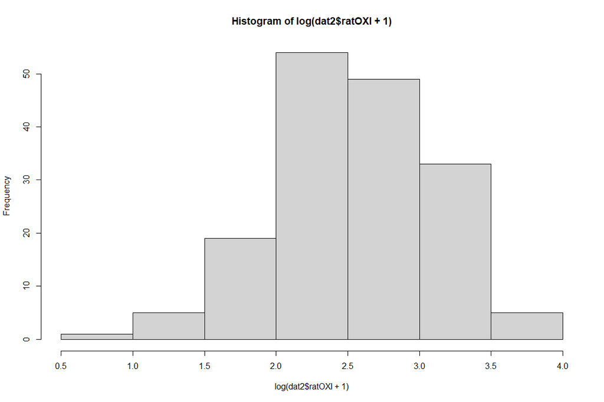

```r
dat2 = dat1[is.na(dat1$mMHCLO) == F, ]
dat2 = dat2[is.na(dat2$mMH2O2) == F, ]
dat2$ratOXI = dat2$mMH2O2 * 1000 / dat2$mMHCLO
hist(log(dat2$ratOXI + 1))
```

### 5.3.2 Visualize

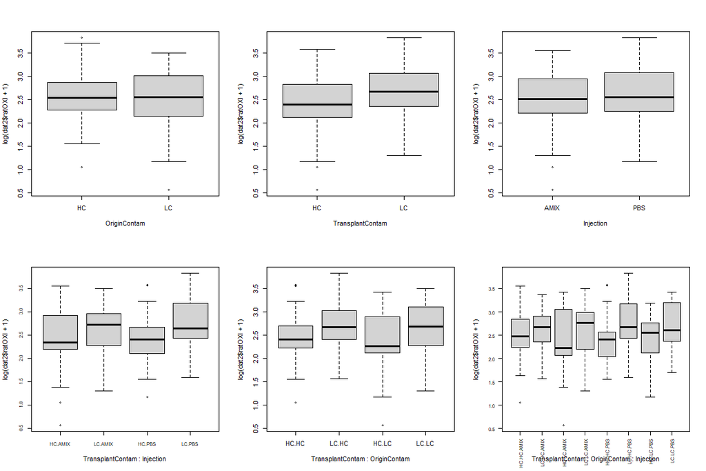

```r
par(mfrow=c(2,3))
boxplot(log(dat2$ratOXI + 1) ~ OriginContam, data = dat2)
boxplot(log(dat2$ratOXI + 1) ~ TransplantContam, data = dat2)
boxplot(log(dat2$ratOXI + 1) ~ Injection, data = dat2)
boxplot(log(dat2$ratOXI + 1) ~ TransplantContam * Injection, data = dat2, cex.axis = 0.8)
boxplot(log(dat2$ratOXI + 1) ~ TransplantContam * OriginContam, data = dat2)
boxplot(log(dat2$ratOXI + 1) ~ TransplantContam * OriginContam * Injection, data = dat2, cex.axis = 0.8, las = 2)
```

### 5.3.3 Build the full model

```r
modfull <-
 lme4::lmer(
    log(ratOXI + 1) ~ (TransplantContam + OriginContam + Injection) ^ 3 +  SizeEnd +
      (1 | CagingSite /  CageSiteID) + (1| OriginSite),
    data = dat2,
    na.action = na.exclude
  )
car::Anova(modfull, type = "3")
```

```
## Analysis of Deviance Table (Type III Wald chisquare tests)
##
## Response: log(ratOXI + 1)
##                                           Chisq Df Pr(>Chisq)
## (Intercept)                             69.2314  1  < 2.2e-16 ***
## TransplantContam                         0.3238  1   0.569314
## OriginContam                             0.0007  1   0.979569
## Injection                                0.0786  1   0.779203
## SizeEnd                                  8.7427  1   0.003108 **
## TransplantContam:OriginContam            0.0505  1   0.822210
## TransplantContam:Injection               1.3823  1   0.239711
## OriginContam:Injection                   0.0913  1   0.762495
## TransplantContam:OriginContam:Injection  0.0696  1   0.791853
## ---
## Signif. codes:  0 '***' 0.001 '**' 0.01 '*' 0.05 '.' 0.1 ' ' 1
```

```r
summary(modfull)
```

```
## Linear mixed model fit by REML ['lmerMod']
## Formula: log(ratOXI + 1) ~ (TransplantContam + OriginContam + Injection)^3 +
##     SizeEnd + (1 | CagingSite/CageSiteID) + (1 | OriginSite)
##    Data: dat2
##
## REML criterion at convergence: 275.1
##
## Scaled residuals:
##     Min      1Q  Median      3Q     Max
## -3.3106 -0.5139  0.0337  0.6605  1.9304
##
## Random effects:
##  Groups                Name        Variance Std.Dev.
##  CageSiteID:CagingSite (Intercept) 0.02445  0.1564
##  CagingSite            (Intercept) 0.00000  0.0000
##  OriginSite            (Intercept) 0.07611  0.2759
##  Residual                          0.25584  0.5058
## Number of obs: 166, groups:
## CageSiteID:CagingSite, 24; CagingSite, 4; OriginSite, 4
##
## Fixed effects:
##                                                 Estimate Std. Error t value
## (Intercept)                                     3.453200   0.415021   8.321
## TransplantContamLC                              0.101436   0.178251   0.569
## OriginContamLC                                 -0.008508   0.332223  -0.026
## InjectionPBS                                   -0.042766   0.152541  -0.280
## SizeEnd                                        -0.100495   0.033988  -2.957
## TransplantContamLC:OriginContamLC              -0.057986   0.258055  -0.225
## TransplantContamLC:InjectionPBS                 0.249744   0.212420   1.176
## OriginContamLC:InjectionPBS                     0.068667   0.227218   0.302
## TransplantContamLC:OriginContamLC:InjectionPBS -0.084638   0.320713  -0.264
##
## Correlation of Fixed Effects:
##             (Intr) TrnCLC OrgCLC InjPBS SizEnd TrCLC:OCLC TCLC:I OCLC:I
## TrnsplntCLC -0.205
## OrignCntmLC -0.414  0.278
## InjectinPBS -0.162  0.457  0.244
## SizeEnd     -0.826 -0.022  0.021 -0.042
## TrnCLC:OCLC  0.136 -0.691 -0.397 -0.316  0.023
## TrnCLC:IPBS  0.080 -0.620 -0.174 -0.719  0.073  0.429
## OrgCLC:IPBS  0.124 -0.306 -0.339 -0.671  0.010  0.436      0.482
## TCLC:OCLC:I -0.066  0.410  0.240  0.476 -0.032 -0.602     -0.661 -0.709
## optimizer (nloptwrap) convergence code: 0 (OK)
## boundary (singular) fit: see ?isSingular
```

### 5.3.4 Refining the model

```r
mod2 <-
 lme4::lmer(
    log(ratOXI + 1) ~ (TransplantContam + OriginContam + Injection) ^ 2 +  SizeEnd +
      (1 | CagingSite /  CageSiteID) + (1| OriginSite),
    data = dat2,
    na.action = na.exclude
  )
car::Anova(mod2, type = "3")
```

```
## Analysis of Deviance Table (Type III Wald chisquare tests)
##
## Response: log(ratOXI + 1)
##                                 Chisq Df Pr(>Chisq)
## (Intercept)                   69.5593  1    < 2e-16 ***
## TransplantContam               0.5469  1    0.45958
## OriginContam                   0.0015  1    0.96941
## Injection                      0.0323  1    0.85744
## SizeEnd                        8.8570  1    0.00292 **
## TransplantContam:OriginContam  0.2313  1    0.63054
## TransplantContam:Injection     1.8062  1    0.17896
## OriginContam:Injection         0.0270  1    0.86949
## ---
## Signif. codes:  0 '***' 0.001 '**' 0.01 '*' 0.05 '.' 0.1 ' ' 1
```

```r
summary(mod2)
```

```
## Linear mixed model fit by REML ['lmerMod']
## Formula: log(ratOXI + 1) ~ (TransplantContam + OriginContam + Injection)^2 +
##     SizeEnd + (1 | CagingSite/CageSiteID) + (1 | OriginSite)
##    Data: dat2
##
## REML criterion at convergence: 274.7
##
## Scaled residuals:
##     Min      1Q  Median      3Q     Max
## -3.3431 -0.5207  0.0314  0.6552  1.9356
##
## Random effects:
##  Groups                Name        Variance  Std.Dev.
##  CageSiteID:CagingSite (Intercept) 2.488e-02 1.577e-01
##  CagingSite            (Intercept) 2.116e-10 1.455e-05
##  OriginSite            (Intercept) 7.611e-02 2.759e-01
##  Residual                          2.540e-01 5.040e-01
## Number of obs: 166, groups:
## CageSiteID:CagingSite, 24; CagingSite, 4; OriginSite, 4
##
## Fixed effects:
##                                   Estimate Std. Error t value
## (Intercept)                        3.44615    0.41320   8.340
## TransplantContamLC                 0.12028    0.16264   0.740
## OriginContamLC                     0.01237    0.32251   0.038
## InjectionPBS                      -0.02402    0.13371  -0.180
## SizeEnd                           -0.10078    0.03386  -2.976
## TransplantContamLC:OriginContamLC -0.09921    0.20628  -0.481
## TransplantContamLC:InjectionPBS    0.21346    0.15883   1.344
## OriginContamLC:InjectionPBS        0.02625    0.15977   0.164
##
## Correlation of Fixed Effects:
##             (Intr) TrnCLC OrgCLC InjPBS SizEnd TCLC:O TCLC:I
## TrnsplntCLC -0.196
## OrignCntmLC -0.412  0.204
## InjectinPBS -0.148  0.325  0.152
## SizeEnd     -0.830 -0.010  0.030 -0.031
## TrnCLC:OCLC  0.121 -0.610 -0.326 -0.042  0.004
## TrnCLC:IPBS  0.048 -0.508 -0.020 -0.614  0.069  0.051
## OrgCLC:IPBS  0.109 -0.025 -0.245 -0.537 -0.018  0.016  0.025
## optimizer (nloptwrap) convergence code: 0 (OK)
## boundary (singular) fit: see ?isSingular
```

### 5.3.5 Refining the model

```r
mod3 <-
 lme4::lmer(
    log(ratOXI + 1) ~ (TransplantContam + OriginContam + Injection) ^ 2 +  SizeEnd +
      (1 | CagingSite /  CageSiteID) + (1| OriginSite),
    data = dat2,
    na.action = na.exclude
  )
car::Anova(mod3, type = "3")
```

```
## Analysis of Deviance Table (Type III Wald chisquare tests)
##
## Response: log(ratOXI + 1)
##                                 Chisq Df Pr(>Chisq)
## (Intercept)                   69.5593  1    < 2e-16 ***
## TransplantContam               0.5469  1    0.45958
## OriginContam                   0.0015  1    0.96941
## Injection                      0.0323  1    0.85744
## SizeEnd                        8.8570  1    0.00292 **
## TransplantContam:OriginContam  0.2313  1    0.63054
## TransplantContam:Injection     1.8062  1    0.17896
## OriginContam:Injection         0.0270  1    0.86949
## ---
## Signif. codes:  0 '***' 0.001 '**' 0.01 '*' 0.05 '.' 0.1 ' ' 1
```

```r
summary(mod3)
```

```
## Linear mixed model fit by REML ['lmerMod']
## Formula: log(ratOXI + 1) ~ (TransplantContam + OriginContam + Injection)^2 +
##     SizeEnd + (1 | CagingSite/CageSiteID) + (1 | OriginSite)
##    Data: dat2
##
## REML criterion at convergence: 274.7
##
## Scaled residuals:
##     Min      1Q  Median      3Q     Max
## -3.3431 -0.5207  0.0314  0.6552  1.9356
##
## Random effects:
##  Groups                Name        Variance  Std.Dev.
##  CageSiteID:CagingSite (Intercept) 2.488e-02 1.577e-01
##  CagingSite            (Intercept) 2.116e-10 1.455e-05
##  OriginSite            (Intercept) 7.611e-02 2.759e-01
##  Residual                          2.540e-01 5.040e-01
## Number of obs: 166, groups:
## CageSiteID:CagingSite, 24; CagingSite, 4; OriginSite, 4
##
## Fixed effects:
##                                   Estimate Std. Error t value
## (Intercept)                        3.44615    0.41320   8.340
## TransplantContamLC                 0.12028    0.16264   0.740
## OriginContamLC                     0.01237    0.32251   0.038
## InjectionPBS                      -0.02402    0.13371  -0.180
## SizeEnd                           -0.10078    0.03386  -2.976
## TransplantContamLC:OriginContamLC -0.09921    0.20628  -0.481
## TransplantContamLC:InjectionPBS    0.21346    0.15883   1.344
## OriginContamLC:InjectionPBS        0.02625    0.15977   0.164
##
## Correlation of Fixed Effects:
##             (Intr) TrnCLC OrgCLC InjPBS SizEnd TCLC:O TCLC:I
## TrnsplntCLC -0.196
## OrignCntmLC -0.412  0.204
## InjectinPBS -0.148  0.325  0.152
## SizeEnd     -0.830 -0.010  0.030 -0.031
## TrnCLC:OCLC  0.121 -0.610 -0.326 -0.042  0.004
## TrnCLC:IPBS  0.048 -0.508 -0.020 -0.614  0.069  0.051
## OrgCLC:IPBS  0.109 -0.025 -0.245 -0.537 -0.018  0.016  0.025
## optimizer (nloptwrap) convergence code: 0 (OK)
## boundary (singular) fit: see ?isSingular
```

### 5.3.6 Refining the model

```r
mod4 <-
 lme4::lmer(
    log(ratOXI + 1) ~ TransplantContam + OriginContam + Injection +  SizeEnd +
      (1 | CagingSite /  CageSiteID) + (1| OriginSite),
    data = dat2,
    na.action = na.exclude
  )
car::Anova(mod4, type = "3")
```

```
## Analysis of Deviance Table (Type III Wald chisquare tests)
##
## Response: log(ratOXI + 1)
##                    Chisq Df Pr(>Chisq)
## (Intercept)      71.3344  1  < 2.2e-16 ***
## TransplantContam  3.5864  1   0.058255 .
## OriginContam      0.0053  1   0.942076
## Injection         1.4256  1   0.232490
## SizeEnd           9.5099  1   0.002044 **
## ---
## Signif. codes:  0 '***' 0.001 '**' 0.01 '*' 0.05 '.' 0.1 ' ' 1
```

```r
summary(mod4)
```

```
## Linear mixed model fit by REML ['lmerMod']
## Formula: log(ratOXI + 1) ~ TransplantContam + OriginContam + Injection +
##     SizeEnd + (1 | CagingSite/CageSiteID) + (1 | OriginSite)
##    Data: dat2
##
## REML criterion at convergence: 271.7
##
## Scaled residuals:
##     Min      1Q  Median      3Q     Max
## -3.1871 -0.5425  0.0135  0.6022  2.0323
##
## Random effects:
##  Groups                Name        Variance  Std.Dev.
##  CageSiteID:CagingSite (Intercept) 1.667e-02 1.291e-01
##  CagingSite            (Intercept) 3.888e-11 6.236e-06
##  OriginSite            (Intercept) 7.776e-02 2.789e-01
##  Residual                          2.567e-01 5.066e-01
## Number of obs: 166, groups:
## CageSiteID:CagingSite, 24; CagingSite, 4; OriginSite, 4
##
## Fixed effects:
##                    Estimate Std. Error t value
## (Intercept)         3.44289    0.40764   8.446
## TransplantContamLC  0.18166    0.09593   1.894
## OriginContamLC     -0.02147    0.29548  -0.073
## InjectionPBS        0.09488    0.07947   1.194
## SizeEnd            -0.10427    0.03381  -3.084
##
## Correlation of Fixed Effects:
##             (Intr) TrnCLC OrgCLC InjPBS
## TrnsplntCLC -0.158
## OrignCntmLC -0.386  0.004
## InjectinPBS -0.106  0.017  0.020
## SizeEnd     -0.846  0.043  0.030  0.003
## optimizer (nloptwrap) convergence code: 0 (OK)
## boundary (singular) fit: see ?isSingular
```

### 5.3.7 Refining the model

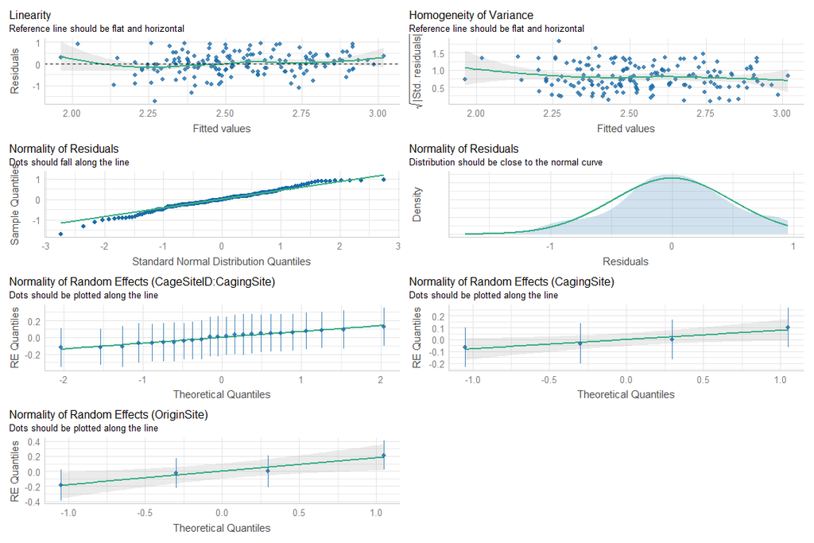

```r
mod5 <-
 lme4::lmer(
    log(ratOXI + 1) ~ SizeEnd +
      (1 | CagingSite /  CageSiteID) + (1| OriginSite),
    data = dat2,
    na.action = na.exclude
  )
performance::check_model(mod5)
```

```r
car::Anova(mod5, type = "3")
```

```
## Analysis of Deviance Table (Type III Wald chisquare tests)
##
## Response: log(ratOXI + 1)
##               Chisq Df Pr(>Chisq)
## (Intercept) 99.4348  1  < 2.2e-16 ***
## SizeEnd      9.2082  1   0.002409 **
## ---
## Signif. codes:  0 '***' 0.001 '**' 0.01 '*' 0.05 '.' 0.1 ' ' 1
```

```r
summary(mod5)
```

```
## Linear mixed model fit by REML ['lmerMod']
## Formula: log(ratOXI + 1) ~ SizeEnd + (1 | CagingSite/CageSiteID) + (1 |
##     OriginSite)
##    Data: dat2
##
## REML criterion at convergence: 269
##
## Scaled residuals:
##     Min      1Q  Median      3Q     Max
## -3.3526 -0.4999  0.0010  0.6396  1.8761
##
## Random effects:
##  Groups                Name        Variance Std.Dev.
##  CageSiteID:CagingSite (Intercept) 0.01830  0.1353
##  CagingSite            (Intercept) 0.01190  0.1091
##  OriginSite            (Intercept) 0.03728  0.1931
##  Residual                          0.25728  0.5072
## Number of obs: 166, groups:
## CageSiteID:CagingSite, 24; CagingSite, 4; OriginSite, 4
##
## Fixed effects:
##             Estimate Std. Error t value
## (Intercept)  3.53866    0.35487   9.972
## SizeEnd     -0.10109    0.03331  -3.034
##
## Correlation of Fixed Effects:
##         (Intr)
## SizeEnd -0.940
```

```r
modRatOx <- mod5
RmodRatOx <- MuMIn::r.squaredGLMM(modRatOx)
```

The treatments has no effect on oxidative stress index but the oxidative stress index is lower in bigger fish Represent the relation between fish size and oxidative stress index

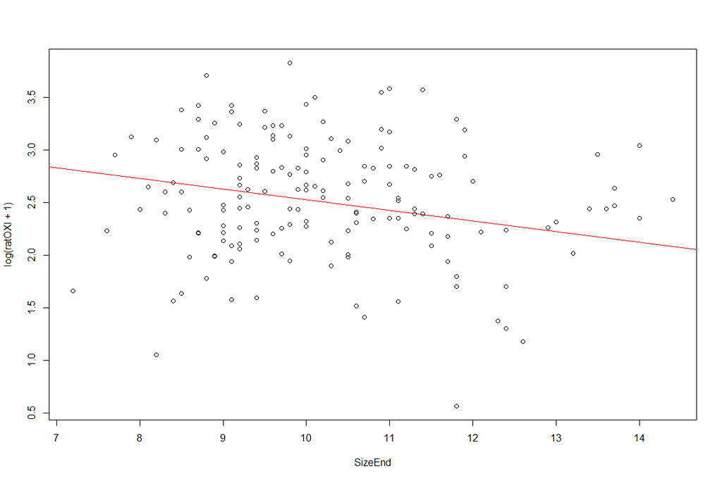

```r
plot(log(ratOXI + 1) ~ SizeEnd, data = dat2)
abline(b = -0.10109, a = 3.53866, col = "red")
```

Now that we have identified the best model, add sex as covariate to check whether results are sensitive NB: sample size is reduced when adding sex variable within the model, for this reason the sex effect on results is checked on the final model

### 5.3.8 Test for the sex effect

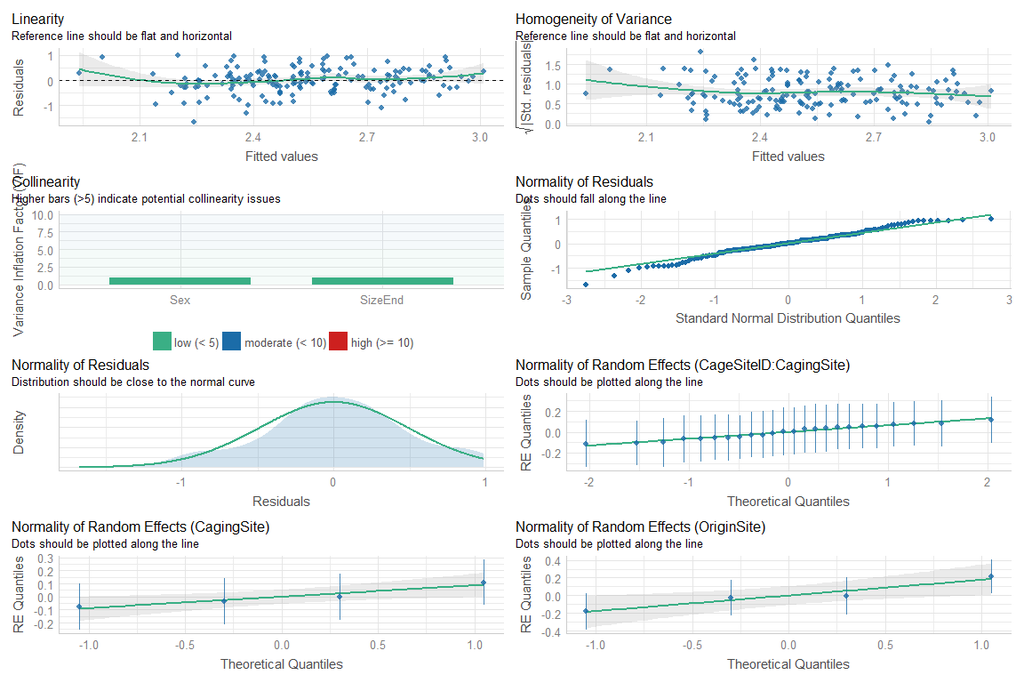

```r
dat2 = dat2[is.na(dat2$Sex) == F, ]
mod5 <-
 lme4::lmer(
    log(ratOXI + 1) ~ SizeEnd + Sex +
      (1 | CagingSite /  CageSiteID) + (1| OriginSite),
    data = dat2,
    na.action = na.exclude
  )
performance::check_model(mod5)
```

```r
car::Anova(mod5, type = "3")
```

```
## Analysis of Deviance Table (Type III Wald chisquare tests)
##
## Response: log(ratOXI + 1)
##              Chisq Df Pr(>Chisq)
## (Intercept) 99.176  1  < 2.2e-16 ***
## SizeEnd      9.413  1   0.002155 **
## Sex          0.145  1   0.703328
## ---
## Signif. codes:  0 '***' 0.001 '**' 0.01 '*' 0.05 '.' 0.1 ' ' 1
```

```r
summary(mod5)
```

```
## Linear mixed model fit by REML ['lmerMod']
## Formula: log(ratOXI + 1) ~ SizeEnd + Sex + (1 | CagingSite/CageSiteID) +
##     (1 | OriginSite)
##    Data: dat2
##
## REML criterion at convergence: 269.6
##
## Scaled residuals:
##     Min      1Q  Median      3Q     Max
## -3.2988 -0.5140  0.0161  0.6177  1.9481
##
## Random effects:
##  Groups                Name        Variance Std.Dev.
##  CageSiteID:CagingSite (Intercept) 0.01693  0.1301
##  CagingSite            (Intercept) 0.01374  0.1172
##  OriginSite            (Intercept) 0.03700  0.1924
##  Residual                          0.25788  0.5078
## Number of obs: 165, groups:
## CageSiteID:CagingSite, 24; CagingSite, 4; OriginSite, 4
##
## Fixed effects:
##             Estimate Std. Error t value
## (Intercept)  3.53925    0.35539   9.959
## SizeEnd     -0.10284    0.03352  -3.068
## SexM         0.03204    0.08413   0.381
##
## Correlation of Fixed Effects:
##         (Intr) SizEnd
## SizeEnd -0.934
## SexM     0.006 -0.109
```

The sex effect is non-significant. The mod5 is thus the best model. Here, there is no interaction, and hence no posthoc test nor parallelism test to conduct

## 5.4 Oxidative damage

### 5.4.1 Check the data

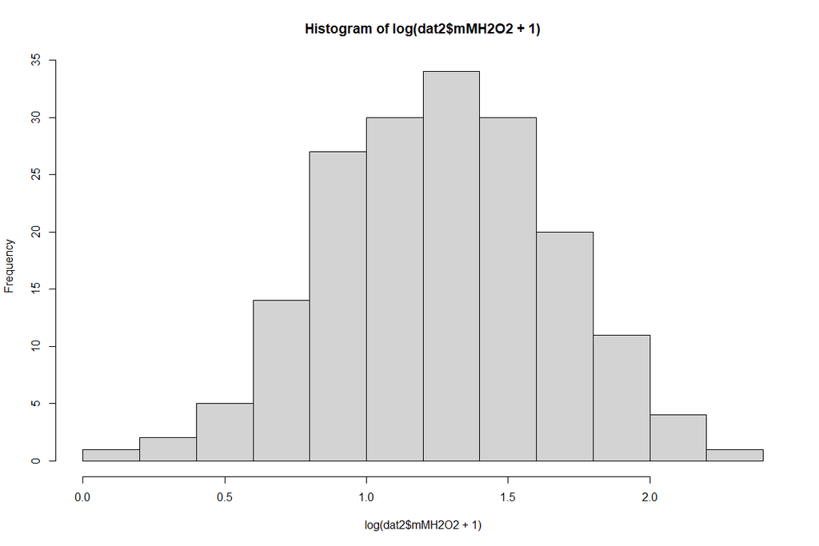

```r
dat2 = dat1[is.na(dat1$mMH2O2) == F, ]
hist(log(dat2$mMH2O2 + 1))
```

### 5.4.2 Visualize

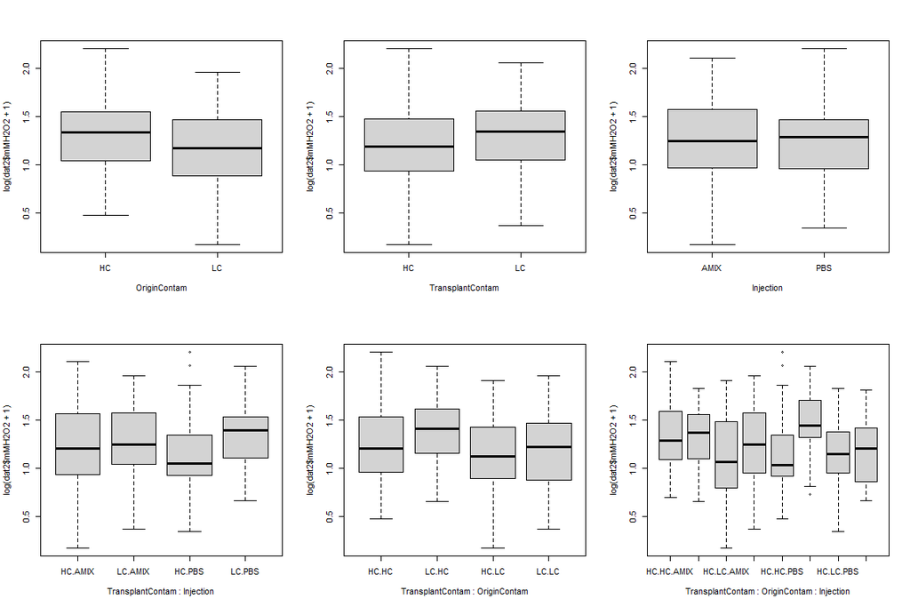

```r
par(mfrow=c(2,3))
boxplot(log(dat2$mMH2O2 + 1) ~ OriginContam, data = dat2)
boxplot(log(dat2$mMH2O2 + 1) ~ TransplantContam, data = dat2)
boxplot(log(dat2$mMH2O2 + 1) ~ Injection, data = dat2)
boxplot(log(dat2$mMH2O2 + 1) ~ TransplantContam * Injection, data = dat2)
boxplot(log(dat2$mMH2O2 + 1) ~ TransplantContam * OriginContam, data = dat2)
boxplot(log(dat2$mMH2O2 + 1) ~ TransplantContam * OriginContam * Injection, data = dat2)
```

### 5.4.3 Build the full model

```r
modfull <-
 lme4::lmer(
    log(mMH2O2 + 1) ~ (TransplantContam + OriginContam + Injection) ^ 3 +  SizeEnd +
      (1 | CagingSite /  CageSiteID) + (1| OriginSite),
    data = dat2,
    na.action = na.exclude
  )
car::Anova(modfull, type = "3")
```

```
## Analysis of Deviance Table (Type III Wald chisquare tests)
##
## Response: log(mMH2O2 + 1)
##                                           Chisq Df Pr(>Chisq)
## (Intercept)                             54.8494  1  1.301e-13 ***
## TransplantContam                         0.0387  1   0.843997
## OriginContam                             0.5331  1   0.465301
## Injection                                3.0090  1   0.082804 .
## SizeEnd                                 12.6086  1   0.000384 ***
## TransplantContam:OriginContam            0.1036  1   0.747597
## TransplantContam:Injection               5.9362  1   0.014833 *
## OriginContam:Injection                   2.2515  1   0.133487
## TransplantContam:OriginContam:Injection  3.4945  1   0.061573 .
## ---
## Signif. codes:  0 '***' 0.001 '**' 0.01 '*' 0.05 '.' 0.1 ' ' 1
```

```r
summary(modfull)
```

```
## Linear mixed model fit by REML ['lmerMod']
## Formula: log(mMH2O2 + 1) ~ (TransplantContam + OriginContam + Injection)^3 +
##     SizeEnd + (1 | CagingSite/CageSiteID) + (1 | OriginSite)
##    Data: dat2
##
## REML criterion at convergence: 166.4
##
## Scaled residuals:
##      Min       1Q   Median       3Q      Max
## -2.56602 -0.62429  0.00728  0.64432  2.55410
##
## Random effects:
##  Groups                Name        Variance Std.Dev.
##  CageSiteID:CagingSite (Intercept) 0.01557  0.1248
##  CagingSite            (Intercept) 0.00000  0.0000
##  OriginSite            (Intercept) 0.04218  0.2054
##  Residual                          0.11756  0.3429
## Number of obs: 179, groups:
## CageSiteID:CagingSite, 24; CagingSite, 4; OriginSite, 4
##
## Fixed effects:
##                                                Estimate Std. Error t value
## (Intercept)                                     2.11280    0.28528   7.406
## TransplantContamLC                             -0.02420    0.12299  -0.197
## OriginContamLC                                 -0.17654    0.24178  -0.730
## InjectionPBS                                   -0.17080    0.09846  -1.735
## SizeEnd                                        -0.08067    0.02272  -3.551
## TransplantContamLC:OriginContamLC               0.05790    0.17991   0.322
## TransplantContamLC:InjectionPBS                 0.33987    0.13949   2.436
## OriginContamLC:InjectionPBS                     0.22025    0.14679   1.500
## TransplantContamLC:OriginContamLC:InjectionPBS -0.38945    0.20834  -1.869
##
## Correlation of Fixed Effects:
##             (Intr) TrnCLC OrgCLC InjPBS SizEnd TrCLC:OCLC TCLC:I OCLC:I
## TrnsplntCLC -0.200
## OrignCntmLC -0.433  0.247
## InjectinPBS -0.141  0.391  0.198
## SizeEnd     -0.806 -0.012  0.024 -0.034
## TrnCLC:OCLC  0.133 -0.684 -0.372 -0.267  0.013
## TrnCLC:IPBS  0.061 -0.575 -0.138 -0.707  0.071  0.394
## OrgCLC:IPBS  0.101 -0.262 -0.303 -0.670  0.014  0.408      0.474
## TCLC:OCLC:I -0.067  0.385  0.214  0.472 -0.015 -0.580     -0.667 -0.705
## optimizer (nloptwrap) convergence code: 0 (OK)
## boundary (singular) fit: see ?isSingular
```

### 5.4.4 Refining the model

```r
mod2 <-
 lme4::lmer(
    log(mMH2O2 + 1) ~ (TransplantContam + OriginContam + Injection) ^ 2 +  SizeEnd +
      (1 | CagingSite /  CageSiteID) + (1| OriginSite),
    data = dat2,
    na.action = na.exclude
  )
car::Anova(mod2, type = "3")
```

```
## Analysis of Deviance Table (Type III Wald chisquare tests)
##
## Response: log(mMH2O2 + 1)
##                                 Chisq Df Pr(>Chisq)
## (Intercept)                   53.0417  1  3.265e-13 ***
## TransplantContam               0.3188  1  0.5723230
## OriginContam                   0.1176  1  0.7316722
## Injection                      0.9171  1  0.3382448
## SizeEnd                       12.5772  1  0.0003905 ***
## TransplantContam:OriginContam  0.8666  1  0.3518981
## TransplantContam:Injection     2.5028  1  0.1136463
## OriginContam:Injection         0.0655  1  0.7980361
## ---
## Signif. codes:  0 '***' 0.001 '**' 0.01 '*' 0.05 '.' 0.1 ' ' 1
```

```r
summary(mod2)
```

```
## Linear mixed model fit by REML ['lmerMod']
## Formula: log(mMH2O2 + 1) ~ (TransplantContam + OriginContam + Injection)^2 +
##     SizeEnd + (1 | CagingSite/CageSiteID) + (1 | OriginSite)
##    Data: dat2
##
## REML criterion at convergence: 168.6
##
## Scaled residuals:
##      Min       1Q   Median       3Q      Max
## -2.69555 -0.59671  0.00027  0.63658  2.41208
##
## Random effects:
##  Groups                Name        Variance  Std.Dev.
##  CageSiteID:CagingSite (Intercept) 1.560e-02 1.249e-01
##  CagingSite            (Intercept) 3.708e-10 1.926e-05
##  OriginSite            (Intercept) 4.090e-02 2.022e-01
##  Residual                          1.194e-01 3.456e-01
## Number of obs: 179, groups:
## CageSiteID:CagingSite, 24; CagingSite, 4; OriginSite, 4
##
## Fixed effects:
##                                   Estimate Std. Error t value
## (Intercept)                        2.07527    0.28495   7.283
## TransplantContamLC                 0.06441    0.11408   0.565
## OriginContamLC                    -0.08016    0.23376  -0.343
## InjectionPBS                      -0.08375    0.08746  -0.958
## SizeEnd                           -0.08111    0.02287  -3.546
## TransplantContamLC:OriginContamLC -0.13701    0.14718  -0.931
## TransplantContamLC:InjectionPBS    0.16564    0.10470   1.582
## OriginContamLC:InjectionPBS        0.02685    0.10493   0.256
##
## Correlation of Fixed Effects:
##             (Intr) TrnCLC OrgCLC InjPBS SizEnd TCLC:O TCLC:I
## TrnsplntCLC -0.190
## OrignCntmLC -0.425  0.186
## InjectinPBS -0.125  0.257  0.115
## SizeEnd     -0.814 -0.007  0.029 -0.030
## TrnCLC:OCLC  0.116 -0.612 -0.316  0.010  0.006
## TrnCLC:IPBS  0.022 -0.465  0.007 -0.597  0.081  0.011
## OrgCLC:IPBS  0.078  0.014 -0.225 -0.540  0.004 -0.002  0.007
## optimizer (nloptwrap) convergence code: 0 (OK)
## boundary (singular) fit: see ?isSingular
```

### 5.4.5 Refining the model

```r
mod3 <-
 lme4::lmer(
    log(mMH2O2 + 1) ~ (TransplantContam + Injection) ^ 2 + OriginContam +  SizeEnd +
      (1 | CagingSite /  CageSiteID) + (1| OriginSite),
    data = dat2,
    na.action = na.exclude
  )
car::Anova(mod3, type = "3")
```

```
## Analysis of Deviance Table (Type III Wald chisquare tests)
##
## Response: log(mMH2O2 + 1)
##                              Chisq Df Pr(>Chisq)
## (Intercept)                55.5203  1   9.25e-14 ***
## TransplantContam            0.0000  1  0.9989045
## Injection                   0.9161  1  0.3384952
## OriginContam                0.3939  1  0.5302729
## SizeEnd                    12.6114  1  0.0003834 ***
## TransplantContam:Injection  2.5040  1  0.1135540
## ---
## Signif. codes:  0 '***' 0.001 '**' 0.01 '*' 0.05 '.' 0.1 ' ' 1
```

```r
summary(mod3)
```

```
## Linear mixed model fit by REML ['lmerMod']
## Formula: log(mMH2O2 + 1) ~ (TransplantContam + Injection)^2 + OriginContam +
##     SizeEnd + (1 | CagingSite/CageSiteID) + (1 | OriginSite)
##    Data: dat2
##
## REML criterion at convergence: 164.9
##
## Scaled residuals:
##     Min      1Q  Median      3Q     Max
## -2.6627 -0.6294  0.0190  0.6121  2.3592
##
## Random effects:
##  Groups                Name        Variance  Std.Dev.
##  CageSiteID:CagingSite (Intercept) 1.450e-02 1.204e-01
##  CagingSite            (Intercept) 5.086e-11 7.132e-06
##  OriginSite            (Intercept) 4.131e-02 2.032e-01
##  Residual                          1.191e-01 3.451e-01
## Number of obs: 179, groups:
## CageSiteID:CagingSite, 24; CagingSite, 4; OriginSite, 4
##
## Fixed effects:
##                                   Estimate Std. Error t value
## (Intercept)                      2.1004046  0.2818883   7.451
## TransplantContamLC               0.0001223  0.0890673   0.001
## InjectionPBS                    -0.0703594  0.0735099  -0.957
## OriginContamLC                  -0.1355283  0.2159505  -0.628
## SizeEnd                         -0.0810685  0.0228282  -3.551
## TransplantContamLC:InjectionPBS  0.1653988  0.1045228   1.582
##
## Correlation of Fixed Effects:
##             (Intr) TrnCLC InjPBS OrgCLC SizEnd
## TrnsplntCLC -0.151
## InjectinPBS -0.101  0.411
## OrignCntmLC -0.407 -0.006 -0.005
## SizeEnd     -0.822 -0.005 -0.033  0.034
## TrnCLC:IPBS  0.021 -0.586 -0.706  0.013  0.082
## optimizer (nloptwrap) convergence code: 0 (OK)
## boundary (singular) fit: see ?isSingular
```

### 5.4.6 Refining the model

```r
mod4 <-
 lme4::lmer(
    log(mMH2O2 + 1) ~ TransplantContam + Injection + OriginContam +  SizeEnd +
      (1 | CagingSite /  CageSiteID) + (1| OriginSite),
    data = dat2,
    na.action = na.exclude
  )
car::Anova(mod4, type = "3")
```

```
## Analysis of Deviance Table (Type III Wald chisquare tests)
##
## Response: log(mMH2O2 + 1)
##                    Chisq Df Pr(>Chisq)
## (Intercept)      54.5200  1  1.539e-13 ***
## TransplantContam  1.4266  1  0.2323242
## Injection         0.0508  1  0.8216143
## OriginContam      0.4177  1  0.5180867
## SizeEnd          13.4376  1  0.0002466 ***
## ---
## Signif. codes:  0 '***' 0.001 '**' 0.01 '*' 0.05 '.' 0.1 ' ' 1
```

```r
summary(mod4)
```

```
## Linear mixed model fit by REML ['lmerMod']
## Formula: log(mMH2O2 + 1) ~ TransplantContam + Injection + OriginContam +
##     SizeEnd + (1 | CagingSite/CageSiteID) + (1 | OriginSite)
##    Data: dat2
##
## REML criterion at convergence: 164.6
##
## Scaled residuals:
##      Min       1Q   Median       3Q      Max
## -2.50161 -0.62349 -0.00387  0.65442  2.23814
##
## Random effects:
##  Groups                Name        Variance Std.Dev.
##  CageSiteID:CagingSite (Intercept) 0.01254  0.1120
##  CagingSite            (Intercept) 0.00000  0.0000
##  OriginSite            (Intercept) 0.04173  0.2043
##  Residual                          0.12105  0.3479
## Number of obs: 179, groups:
## CageSiteID:CagingSite, 24; CagingSite, 4; OriginSite, 4
##
## Fixed effects:
##                    Estimate Std. Error t value
## (Intercept)         2.09001    0.28305   7.384
## TransplantContamLC  0.08377    0.07014   1.194
## InjectionPBS        0.01183    0.05248   0.225
## OriginContamLC     -0.13976    0.21624  -0.646
## SizeEnd            -0.08393    0.02290  -3.666
##
## Correlation of Fixed Effects:
##             (Intr) TrnCLC InjPBS OrgCLC
## TrnsplntCLC -0.169
## InjectinPBS -0.123 -0.004
## OrignCntmLC -0.407  0.001  0.006
## SizeEnd     -0.828  0.055  0.034  0.033
## optimizer (nloptwrap) convergence code: 0 (OK)
## boundary (singular) fit: see ?isSingular
```

### 5.4.7 Refining the model

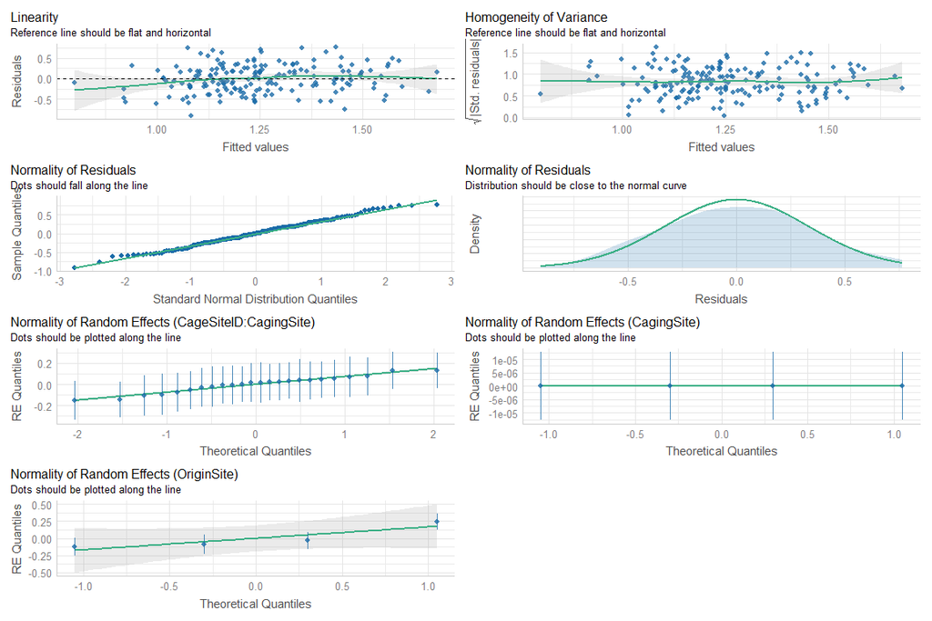

```r
mod5 <-
 lme4::lmer(
    log(mMH2O2 + 1) ~ SizeEnd +
      (1 | CagingSite /  CageSiteID) + (1| OriginSite),
    data = dat2,
    na.action = na.exclude
  )
performance::check_model(mod5)
```

```r
car::Anova(mod5, type = "3")
```

```
## Analysis of Deviance Table (Type III Wald chisquare tests)
##
## Response: log(mMH2O2 + 1)
##              Chisq Df Pr(>Chisq)
## (Intercept) 70.728  1  < 2.2e-16 ***
## SizeEnd     13.668  1  0.0002182 ***
## ---
## Signif. codes:  0 '***' 0.001 '**' 0.01 '*' 0.05 '.' 0.1 ' ' 1
```

```r
summary(mod5)
```

```
## Linear mixed model fit by REML ['lmerMod']
## Formula: log(mMH2O2 + 1) ~ SizeEnd + (1 | CagingSite/CageSiteID) + (1 |
##     OriginSite)
##    Data: dat2
##
## REML criterion at convergence: 157.7
##
## Scaled residuals:
##      Min       1Q   Median       3Q      Max
## -2.61419 -0.65373  0.00172  0.62497  2.21411
##
## Random effects:
##  Groups                Name        Variance  Std.Dev.
##  CageSiteID:CagingSite (Intercept) 1.400e-02 1.183e-01
##  CagingSite            (Intercept) 4.228e-11 6.502e-06
##  OriginSite            (Intercept) 3.266e-02 1.807e-01
##  Residual                          1.199e-01 3.463e-01
## Number of obs: 179, groups:
## CageSiteID:CagingSite, 24; CagingSite, 4; OriginSite, 4
##
## Fixed effects:
##             Estimate Std. Error t value
## (Intercept)  2.06737    0.24582   8.410
## SizeEnd     -0.08377    0.02266  -3.697
##
## Correlation of Fixed Effects:
##         (Intr)
## SizeEnd -0.918
## optimizer (nloptwrap) convergence code: 0 (OK)
## boundary (singular) fit: see ?isSingular
```

```r
modOXDam <- mod5
RmodOXDam <- MuMIn::r.squaredGLMM(modOXDam)
```

The treatments has no effect on oxidative damage but the oxidative damage are lower in bigger fish Represent the relation between fish size and oxidative damage

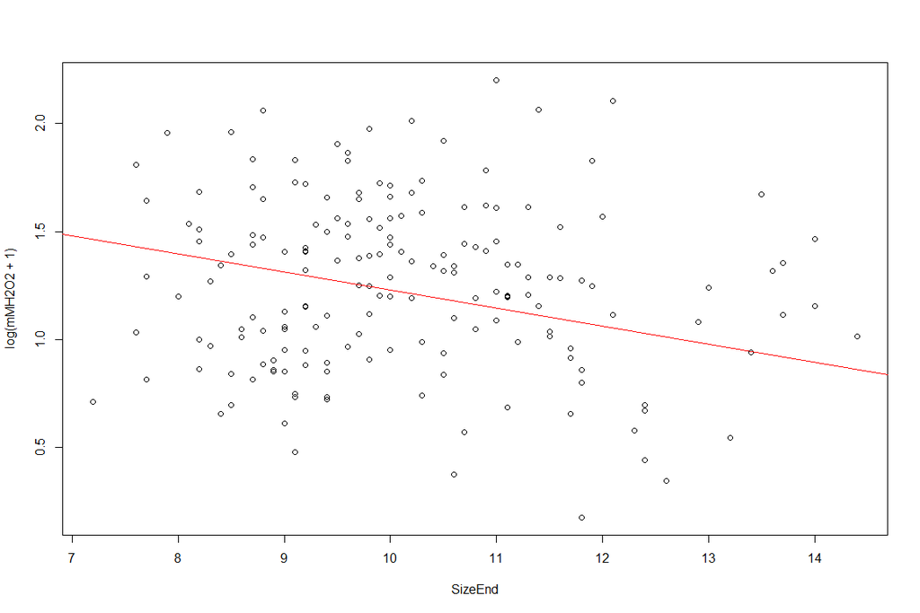

```r
plot(log(mMH2O2 + 1) ~ SizeEnd, data = dat2)
abline(b = -0.08377, a = 2.06737, col = "red")
```

Now that we have identified the best model, add sex as covariate to check whether results are sensitive NB: sample size is reduced when adding sex variable within the model, for this reason the sex effect on results is checked on the final model

### 5.4.8 Test for the sex effect

```r
dat2 = dat2[is.na(dat2$Sex) == F, ]
modSex <-
 lme4::lmer(
    log(mMH2O2 + 1) ~ SizeEnd + Sex +
      (1 | CagingSite /  CageSiteID) + (1| OriginSite),
    data = dat2,
    na.action = na.exclude
  )
car::Anova(modSex, type = "3")
```

```
## Analysis of Deviance Table (Type III Wald chisquare tests)
##
## Response: log(mMH2O2 + 1)
##               Chisq Df Pr(>Chisq)
## (Intercept) 70.9360  1  < 2.2e-16 ***
## SizeEnd     13.8796  1  0.0001949 ***
## Sex          0.0402  1  0.8411112
## ---
## Signif. codes:  0 '***' 0.001 '**' 0.01 '*' 0.05 '.' 0.1 ' ' 1
```

```r
summary(modSex)
```

```
## Linear mixed model fit by REML ['lmerMod']
## Formula: log(mMH2O2 + 1) ~ SizeEnd + Sex + (1 | CagingSite/CageSiteID) +
##     (1 | OriginSite)
##    Data: dat2
##
## REML criterion at convergence: 158.3
##
## Scaled residuals:
##      Min       1Q   Median       3Q      Max
## -2.50997 -0.63249  0.01078  0.65634  2.33837
##
## Random effects:
##  Groups                Name        Variance Std.Dev.
##  CageSiteID:CagingSite (Intercept) 0.01358  0.1165
##  CagingSite            (Intercept) 0.00000  0.0000
##  OriginSite            (Intercept) 0.03354  0.1831
##  Residual                          0.11895  0.3449
## Number of obs: 178, groups:
## CageSiteID:CagingSite, 24; CagingSite, 4; OriginSite, 4
##
## Fixed effects:
##             Estimate Std. Error t value
## (Intercept)  2.06736    0.24546   8.422
## SizeEnd     -0.08459    0.02271  -3.726
## SexM         0.01120    0.05585   0.200
##
## Correlation of Fixed Effects:
##         (Intr) SizEnd
## SizeEnd -0.912
## SexM     0.005 -0.107
## optimizer (nloptwrap) convergence code: 0 (OK)
## boundary (singular) fit: see ?isSingular
```

The sex effect is non-significant. The mod5 is thus the best model. Here, there is no interaction, and hence no posthoc test nor parallelism test to conduct

## 5.5 Antiox. Capacity

### 5.5.1 Check the data

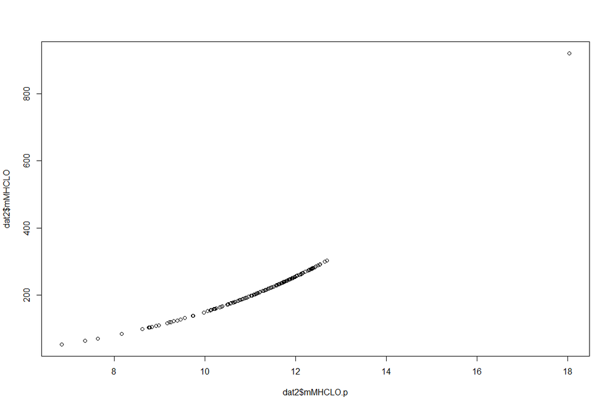

```r
dat2 = dat1[is.na(dat1$mMHCLO) == F, ]
# transform variable to approx. normality
dat2$mMHCLO.p <-
  bimixt::boxcox(dat2$mMHCLO, car::powerTransform(dat2$mMHCLO)$lambda)
plot(dat2$mMHCLO.p, dat2$mMHCLO)
```

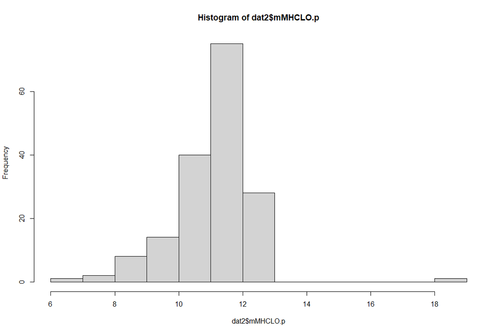

```r
hist(dat2$mMHCLO.p)
```

### 5.5.2 Visualize

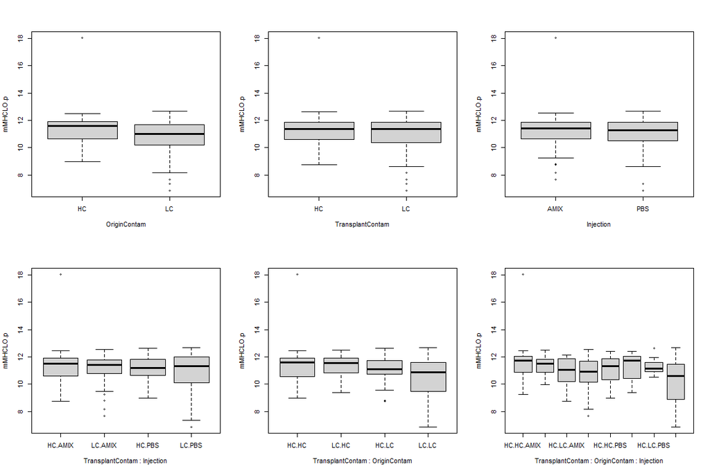

```r
par(mfrow=c(2,3))
boxplot(mMHCLO.p ~ OriginContam, data = dat2)
boxplot(mMHCLO.p ~ TransplantContam, data = dat2)
boxplot(mMHCLO.p ~ Injection, data = dat2)
boxplot(mMHCLO.p ~ TransplantContam * Injection, data = dat2)
boxplot(mMHCLO.p ~ TransplantContam * OriginContam, data = dat2)
boxplot(mMHCLO.p ~ TransplantContam * OriginContam * Injection, data = dat2)
```

### 5.5.3 Build the full model

```r
modfull <-
 lme4::lmer(
    mMHCLO.p ~ (TransplantContam + OriginContam + Injection) ^ 3 +  SizeEnd +
      (1 | CagingSite /  CageSiteID) + (1| OriginSite),
    data = dat2,
    na.action = na.exclude
  )
car::Anova(modfull, type = "3")
```

```
## Analysis of Deviance Table (Type III Wald chisquare tests)
##
## Response: mMHCLO.p
##                                            Chisq Df Pr(>Chisq)
## (Intercept)                             233.3662  1    < 2e-16 ***
## TransplantContam                          0.4058  1    0.52413
## OriginContam                              2.9468  1    0.08605 .
## Injection                                 1.7544  1    0.18532
## SizeEnd                                   0.3068  1    0.57967
## TransplantContam:OriginContam             0.0314  1    0.85939
## TransplantContam:Injection                0.6411  1    0.42330
## OriginContam:Injection                    2.4429  1    0.11806
## TransplantContam:OriginContam:Injection   3.0174  1    0.08238 .
## ---
## Signif. codes:  0 '***' 0.001 '**' 0.01 '*' 0.05 '.' 0.1 ' ' 1
```

```r
summary(modfull)
```

```
## Linear mixed model fit by REML ['lmerMod']
## Formula: mMHCLO.p ~ (TransplantContam + OriginContam + Injection)^3 +
##     SizeEnd + (1 | CagingSite/CageSiteID) + (1 | OriginSite)
##    Data: dat2
##
## REML criterion at convergence: 541.7
##
## Scaled residuals:
##     Min      1Q  Median      3Q     Max
## -2.7540 -0.5760  0.1430  0.6006  5.3445
##
## Random effects:
##  Groups                Name        Variance  Std.Dev.
##  CageSiteID:CagingSite (Intercept) 1.662e-10 1.289e-05
##  CagingSite            (Intercept) 0.000e+00 0.000e+00
##  OriginSite            (Intercept) 4.487e-02 2.118e-01
##  Residual                          1.419e+00 1.191e+00
## Number of obs: 169, groups:
## CageSiteID:CagingSite, 24; CagingSite, 4; OriginSite, 4
##
## Fixed effects:
##                                                Estimate Std. Error t value
## (Intercept)                                    11.99105    0.78494  15.276
## TransplantContamLC                             -0.22155    0.34781  -0.637
## OriginContamLC                                 -0.72751    0.42380  -1.717
## InjectionPBS                                   -0.46049    0.34766  -1.325
## SizeEnd                                        -0.03909    0.07057  -0.554
## TransplantContamLC:OriginContamLC               0.09041    0.51039   0.177
## TransplantContamLC:InjectionPBS                 0.39216    0.48976   0.801
## OriginContamLC:InjectionPBS                     0.82024    0.52479   1.563
## TransplantContamLC:OriginContamLC:InjectionPBS -1.28948    0.74234  -1.737
##
## Correlation of Fixed Effects:
##             (Intr) TrnCLC OrgCLC InjPBS SizEnd TrCLC:OCLC TCLC:I OCLC:I
## TrnsplntCLC -0.222
## OrignCntmLC -0.311  0.417
## InjectinPBS -0.227  0.510  0.420
## SizeEnd     -0.929 -0.003  0.061  0.001
## TrnCLC:OCLC  0.122 -0.682 -0.614 -0.347  0.034
## TrnCLC:IPBS  0.113 -0.710 -0.293 -0.709  0.051  0.486
## OrgCLC:IPBS  0.166 -0.338 -0.598 -0.662 -0.017  0.495      0.469
## TCLC:OCLC:I -0.074  0.469  0.421  0.468 -0.033 -0.688     -0.660 -0.706
## optimizer (nloptwrap) convergence code: 0 (OK)
## boundary (singular) fit: see ?isSingular
```

### 5.5.4 Refining the model

```r
mod2 <-
 lme4::lmer(
    mMHCLO.p~ (TransplantContam + OriginContam + Injection) ^ 2 +  SizeEnd +
      (1 | CagingSite /  CageSiteID) + (1| OriginSite),
    data = dat2,
    na.action = na.exclude
  )
car::Anova(mod2, type = "3")
```

```
## Analysis of Deviance Table (Type III Wald chisquare tests)
##
## Response: mMHCLO.p
##                                  Chisq Df Pr(>Chisq)
## (Intercept)                   230.6349  1     <2e-16 ***
## TransplantContam                0.0392  1     0.8430
## OriginContam                    1.1930  1     0.2747
## Injection                       0.3317  1     0.5646
## SizeEnd                         0.3452  1     0.5569
## TransplantContam:OriginContam   1.9466  1     0.1630
## TransplantContam:Injection      0.2054  1     0.6504
## OriginContam:Injection          0.2239  1     0.6361
## ---
## Signif. codes:  0 '***' 0.001 '**' 0.01 '*' 0.05 '.' 0.1 ' ' 1
```

```r
summary(mod2)
```

```
## Linear mixed model fit by REML ['lmerMod']
## Formula: mMHCLO.p ~ (TransplantContam + OriginContam + Injection)^2 +
##     SizeEnd + (1 | CagingSite/CageSiteID) + (1 | OriginSite)
##    Data: dat2
##
## REML criterion at convergence: 545.9
##
## Scaled residuals:
##     Min      1Q  Median      3Q     Max
## -2.8958 -0.5804  0.1787  0.6118  5.4241
##
## Random effects:
##  Groups                Name        Variance Std.Dev.
##  CageSiteID:CagingSite (Intercept) 0.00000  0.0000
##  CagingSite            (Intercept) 0.00000  0.0000
##  OriginSite            (Intercept) 0.03975  0.1994
##  Residual                          1.43820  1.1992
## Number of obs: 169, groups:
## CageSiteID:CagingSite, 24; CagingSite, 4; OriginSite, 4
##
## Fixed effects:
##                                   Estimate Std. Error t value
## (Intercept)                       11.87136    0.78170  15.187
## TransplantContamLC                 0.06125    0.30928   0.198
## OriginContamLC                    -0.41438    0.37938  -1.092
## InjectionPBS                      -0.17813    0.30927  -0.576
## SizeEnd                           -0.04141    0.07049  -0.588
## TransplantContamLC:OriginContamLC -0.52047    0.37304  -1.395
## TransplantContamLC:InjectionPBS   -0.16791    0.37048  -0.453
## OriginContamLC:InjectionPBS        0.17703    0.37413   0.473
##
## Correlation of Fixed Effects:
##             (Intr) TrnCLC OrgCLC InjPBS SizEnd TCLC:O TCLC:I
## TrnsplntCLC -0.214
## OrignCntmLC -0.307  0.280
## InjectinPBS -0.220  0.372  0.283
## SizeEnd     -0.936  0.013  0.084  0.019
## TrnCLC:OCLC  0.098 -0.560 -0.502 -0.040  0.016
## TrnCLC:IPBS  0.086 -0.604 -0.023 -0.603  0.038  0.059
## OrgCLC:IPBS  0.162 -0.011 -0.478 -0.531 -0.058  0.018  0.006
## optimizer (nloptwrap) convergence code: 0 (OK)
## boundary (singular) fit: see ?isSingular
```

### 5.5.5 Refining the model

```r
mod3 <-
 lme4::lmer(
    mMHCLO.p ~ (TransplantContam + OriginContam ) ^ 2 + Injection +  SizeEnd +
      (1 | CagingSite /  CageSiteID) + (1| OriginSite),
    data = dat2,
    na.action = na.exclude
  )
car::Anova(mod3, type = "3")
```

```
## Analysis of Deviance Table (Type III Wald chisquare tests)
##
## Response: mMHCLO.p
##                                  Chisq Df Pr(>Chisq)
## (Intercept)                   240.1201  1     <2e-16 ***
## TransplantContam                0.0083  1     0.9274
## OriginContam                    1.0066  1     0.3157
## Injection                       1.0082  1     0.3153
## SizeEnd                         0.2955  1     0.5867
## TransplantContam:OriginContam   1.9226  1     0.1656
## ---
## Signif. codes:  0 '***' 0.001 '**' 0.01 '*' 0.05 '.' 0.1 ' ' 1
```

```r
summary(mod3)
```

```
## Linear mixed model fit by REML ['lmerMod']
## Formula: mMHCLO.p ~ (TransplantContam + OriginContam)^2 + Injection +
##     SizeEnd + (1 | CagingSite/CageSiteID) + (1 | OriginSite)
##    Data: dat2
##
## REML criterion at convergence: 546.1
##
## Scaled residuals:
##     Min      1Q  Median      3Q     Max
## -2.9016 -0.5463  0.1922  0.6084  5.4537
##
## Random effects:
##  Groups                Name        Variance Std.Dev.
##  CageSiteID:CagingSite (Intercept) 0.0000   0.0000
##  CagingSite            (Intercept) 0.0000   0.0000
##  OriginSite            (Intercept) 0.0387   0.1967
##  Residual                          1.4245   1.1935
## Number of obs: 169, groups:
## CageSiteID:CagingSite, 24; CagingSite, 4; OriginSite, 4
##
## Fixed effects:
##                                   Estimate Std. Error t value
## (Intercept)                       11.83934    0.76403  15.496
## TransplantContamLC                -0.02235    0.24524  -0.091
## OriginContamLC                    -0.33167    0.33057  -1.003
## InjectionPBS                      -0.18506    0.18430  -1.004
## SizeEnd                           -0.03801    0.06992  -0.544
## TransplantContamLC:OriginContamLC -0.51381    0.37056  -1.387
##
## Correlation of Fixed Effects:
##             (Intr) TrnCLC OrgCLC InjPBS SizEnd
## TrnsplntCLC -0.205
## OrignCntmLC -0.264  0.376
## InjectinPBS -0.142  0.008  0.034
## SizeEnd     -0.948  0.045  0.065  0.019
## TrnCLC:OCLC  0.092 -0.660 -0.564  0.008  0.015
## optimizer (nloptwrap) convergence code: 0 (OK)
## boundary (singular) fit: see ?isSingular
```

### 5.5.6 Refining the model

```r
mod4 <-
 lme4::lmer(
    mMHCLO.p ~ TransplantContam + Injection + OriginContam +  SizeEnd +
      (1 | CagingSite /  CageSiteID) + (1| OriginSite),
    data = dat2,
    na.action = na.exclude
  )
car::Anova(mod4, type = "3")
```

```
## Analysis of Deviance Table (Type III Wald chisquare tests)
##
## Response: mMHCLO.p
##                     Chisq Df Pr(>Chisq)
## (Intercept)      241.0178  1    < 2e-16 ***
## TransplantContam   1.7770  1    0.18252
## Injection          0.9884  1    0.32012
## OriginContam       4.2989  1    0.03814 *
## SizeEnd            0.3013  1    0.58308
## ---
## Signif. codes:  0 '***' 0.001 '**' 0.01 '*' 0.05 '.' 0.1 ' ' 1
```

```r
summary(mod4)
```

```
## Linear mixed model fit by REML ['lmerMod']
## Formula: mMHCLO.p ~ TransplantContam + Injection + OriginContam + SizeEnd +
##     (1 | CagingSite/CageSiteID) + (1 | OriginSite)
##    Data: dat2
##
## REML criterion at convergence: 547.8
##
## Scaled residuals:
##     Min      1Q  Median      3Q     Max
## -2.9991 -0.5639  0.1525  0.6239  5.3481
##
## Random effects:
##  Groups                Name        Variance Std.Dev.
##  CageSiteID:CagingSite (Intercept) 0.00000  0.000
##  CagingSite            (Intercept) 0.00000  0.000
##  OriginSite            (Intercept) 0.04579  0.214
##  Residual                          1.43108  1.196
## Number of obs: 169, groups:
## CageSiteID:CagingSite, 24; CagingSite, 4; OriginSite, 4
##
## Fixed effects:
##                    Estimate Std. Error t value
## (Intercept)        11.95948    0.77035  15.525
## TransplantContamLC -0.24628    0.18475  -1.333
## InjectionPBS       -0.18366    0.18473  -0.994
## OriginContamLC     -0.59335    0.28618  -2.073
## SizeEnd            -0.03880    0.07069  -0.549
##
## Correlation of Fixed Effects:
##             (Intr) TrnCLC InjPBS OrgCLC
## TrnsplntCLC -0.192
## InjectinPBS -0.142  0.018
## OrignCntmLC -0.261  0.006  0.044
## SizeEnd     -0.952  0.074  0.019  0.085
## optimizer (nloptwrap) convergence code: 0 (OK)
## boundary (singular) fit: see ?isSingular
```

### 5.5.7 Refining the model

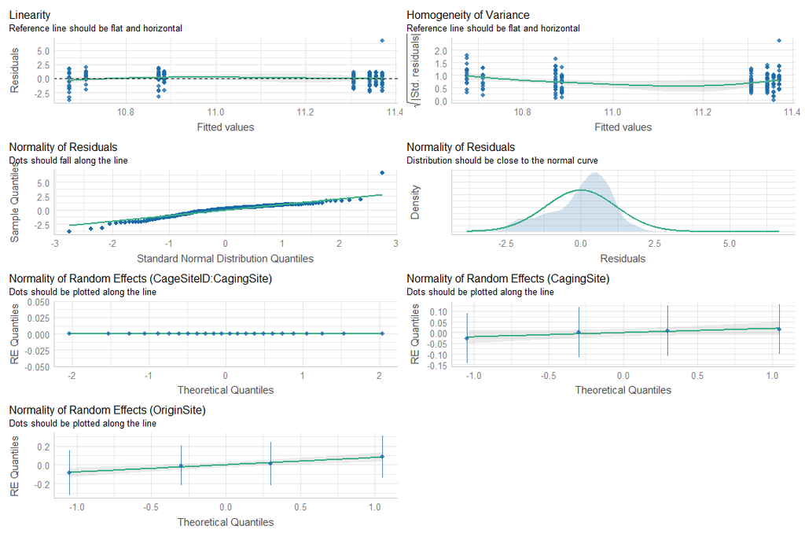

```r
mod5 <-
 lme4::lmer(
    mMHCLO.p ~ OriginContam +
      (1 | CagingSite /  CageSiteID) + (1| OriginSite),
    data = dat2,
    na.action = na.exclude
  )
performance::check_model(mod5)
```

```r
car::Anova(mod5, type = "3")
```

```
## Analysis of Deviance Table (Type III Wald chisquare tests)
##
## Response: mMHCLO.p
##                  Chisq Df Pr(>Chisq)
## (Intercept)  4829.6889  1    < 2e-16 ***
## OriginContam    5.5915  1    0.01805 *
## ---
## Signif. codes:  0 '***' 0.001 '**' 0.01 '*' 0.05 '.' 0.1 ' ' 1
```

```r
summary(mod5)
```

```
## Linear mixed model fit by REML ['lmerMod']
## Formula: mMHCLO.p ~ OriginContam + (1 | CagingSite/CageSiteID) + (1 |
##     OriginSite)
##    Data: dat2
##
## REML criterion at convergence: 544.1
##
## Scaled residuals:
##     Min      1Q  Median      3Q     Max
## -3.1941 -0.5074  0.2039  0.6000  5.5700
##
## Random effects:
##  Groups                Name        Variance Std.Dev.
##  CageSiteID:CagingSite (Intercept) 0.000000 0.00000
##  CagingSite            (Intercept) 0.003901 0.06246
##  OriginSite            (Intercept) 0.020520 0.14325
##  Residual                          1.433492 1.19729
## Number of obs: 169, groups:
## CageSiteID:CagingSite, 24; CagingSite, 4; OriginSite, 4
##
## Fixed effects:
##                Estimate Std. Error t value
## (Intercept)     11.3444     0.1632  69.496
## OriginContamLC  -0.5580     0.2360  -2.365
##
## Correlation of Fixed Effects:
##             (Intr)
## OrignCntmLC -0.667
## optimizer (nloptwrap) convergence code: 0 (OK)
## boundary (singular) fit: see ?isSingular
```

```r
modantiOx <- mod5
RmodantiOx <- MuMIn::r.squaredGLMM(modantiOx)
```

The origin of the fish affects the non-enzymatic antioxidant capacity (measured in plasma), With HC fish having higher non-enzymatic antioxidant capacity than fish from LC sites (see boxplot and table below).

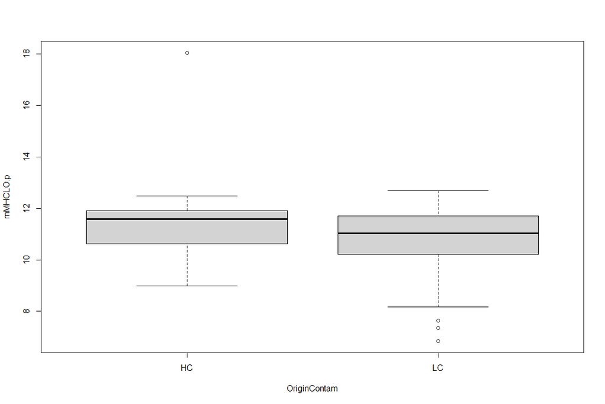

```r
boxplot(mMHCLO.p ~ OriginContam, data = dat2)
```

```r
# compute mean and Se for LC and HC groups (on raw antioxidant capacity data - not transformed)
meanVal <-
  data.frame(
    mean = c(mean(dat2$mMHCLO[which(dat2$OriginContam == "LC")]),
             mean(dat2$mMHCLO[which(dat2$OriginContam == "HC")])),
    Se = c(
      sd(dat2$mMHCLO[which(dat2$OriginContam == "LC")]) / sqrt(length(dat2$mMHCLO[which(dat2$OriginContam == "LC")])),
      sd(dat2$mMHCLO[which(dat2$OriginContam == "HC")]) / sqrt(length(dat2$mMHCLO[which(dat2$OriginContam == "HC")]))
    ),
    row.names = c("LC", "HC")
  )
kableExtra::kable_classic(
  kableExtra::kbl(meanVal),
  bootstrap_options = c("striped", "hover", "condensed", "responsive"),
  full_width = F,
  html_font = "arial",
  font_size = 10
)
```

|  | mean | Se |
| --- | --- | --- |
| LC | 195.3241 | 6.786571 |
| HC | 223.7893 | 8.853048 |

Now that we have identified the best model, add sex as covariate to check whether results are sensitive NB: sample size is reduced when adding sex variable within the model, for this reason the sex effect on results is checked on the final model

### 5.5.8 Test for the sex effect

```r
dat2 = dat2[is.na(dat2$Sex) == F, ]
modSex <-
 lme4::lmer(
    mMHCLO.p ~ OriginContam + Sex +
      (1 | CagingSite /  CageSiteID) + (1| OriginSite),
    data = dat2,
    na.action = na.exclude
  )
car::Anova(modSex, type = "3")
```

```
## Analysis of Deviance Table (Type III Wald chisquare tests)
##
## Response: mMHCLO.p
##                  Chisq Df Pr(>Chisq)
## (Intercept)  5096.4526  1    < 2e-16 ***
## OriginContam    7.5057  1    0.00615 **
## Sex             0.5553  1    0.45615
## ---
## Signif. codes:  0 '***' 0.001 '**' 0.01 '*' 0.05 '.' 0.1 ' ' 1
```

```r
summary(modSex)
```

```
## Linear mixed model fit by REML ['lmerMod']
## Formula: mMHCLO.p ~ OriginContam + Sex + (1 | CagingSite/CageSiteID) +
##     (1 | OriginSite)
##    Data: dat2
##
## REML criterion at convergence: 542
##
## Scaled residuals:
##     Min      1Q  Median      3Q     Max
## -3.1498 -0.5333  0.1974  0.5922  5.5104
##
## Random effects:
##  Groups                Name        Variance  Std.Dev.
##  CageSiteID:CagingSite (Intercept) 1.642e-09 4.052e-05
##  CagingSite            (Intercept) 4.225e-03 6.500e-02
##  OriginSite            (Intercept) 6.740e-03 8.210e-02
##  Residual                          1.443e+00 1.201e+00
## Number of obs: 168, groups:
## CageSiteID:CagingSite, 24; CagingSite, 4; OriginSite, 4
##
## Fixed effects:
##                Estimate Std. Error t value
## (Intercept)     11.4000     0.1597  71.389
## OriginContamLC  -0.5620     0.2051  -2.740
## SexM            -0.1414     0.1897  -0.745
##
## Correlation of Fixed Effects:
##             (Intr) OrgCLC
## OrignCntmLC -0.571
## SexM        -0.473 -0.002
## optimizer (nloptwrap) convergence code: 0 (OK)
## boundary (singular) fit: see ?isSingular
```

The sex effect is non-significant. The mod5 is thus the best model. Here, there is no interaction, and hence no posthoc test nor parallelism test to conduct

## 5.6 local inflammatory Response

### 5.6.1 Check the data

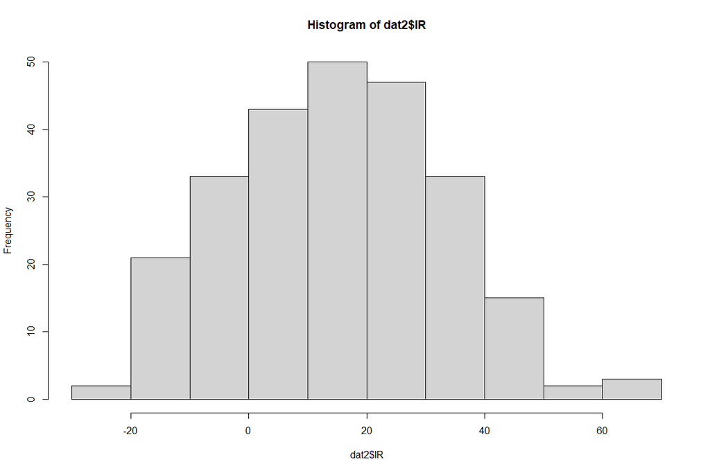

```r
dat2 = dat1[is.na(dat1$IR) == F, ]
hist(dat2$IR)
```

### 5.6.2 Visualize

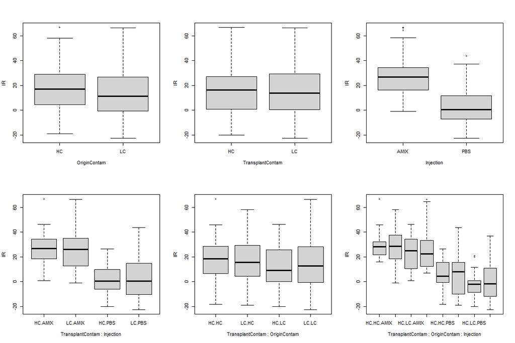

```r
par(mfrow=c(2,3))
boxplot(IR ~ OriginContam, data = dat2)
boxplot(IR ~ TransplantContam, data = dat2)
boxplot(IR ~ Injection, data = dat2)
boxplot(IR ~ TransplantContam * Injection, data = dat2)
boxplot(IR ~ TransplantContam * OriginContam, data = dat2)
boxplot(IR ~ TransplantContam * OriginContam * Injection, data = dat2)
```

### 5.6.3 Build the full model

```r
modfull <-
 lme4::lmer(
    IR ~ (TransplantContam + OriginContam + Injection) ^ 3 +  SizeEnd + IRTime +
      (1 | CagingSite /  CageSiteID) + (1| OriginSite),
    data = dat2,
    na.action = na.exclude
  )
car::Anova(modfull, type = "3")
```

```
## Analysis of Deviance Table (Type III Wald chisquare tests)
##
## Response: IR
##                                           Chisq Df Pr(>Chisq)
## (Intercept)                              2.0173  1     0.1555
## TransplantContam                         1.5175  1     0.2180
## OriginContam                             2.5784  1     0.1083
## Injection                               49.8556  1  1.655e-12 ***
## SizeEnd                                  0.4385  1     0.5079
## IRTime                                   2.0751  1     0.1497
## TransplantContam:OriginContam            0.3677  1     0.5443
## TransplantContam:Injection               0.3178  1     0.5729
## OriginContam:Injection                   0.0781  1     0.7799
## TransplantContam:OriginContam:Injection  0.1481  1     0.7004
## ---
## Signif. codes:  0 '***' 0.001 '**' 0.01 '*' 0.05 '.' 0.1 ' ' 1
```

```r
summary(modfull)
```

```
## Linear mixed model fit by REML ['lmerMod']
## Formula: IR ~ (TransplantContam + OriginContam + Injection)^3 + SizeEnd +
##     IRTime + (1 | CagingSite/CageSiteID) + (1 | OriginSite)
##    Data: dat2
##
## REML criterion at convergence: 1939.2
##
## Scaled residuals:
##      Min       1Q   Median       3Q      Max
## -2.61224 -0.67264 -0.07626  0.66819  2.77716
##
## Random effects:
##  Groups                Name        Variance  Std.Dev.
##  CageSiteID:CagingSite (Intercept) 1.013e+01 3.182e+00
##  CagingSite            (Intercept) 1.495e+01 3.867e+00
##  OriginSite            (Intercept) 2.309e-08 1.519e-04
##  Residual                          1.735e+02 1.317e+01
## Number of obs: 247, groups:
## CageSiteID:CagingSite, 24; CagingSite, 4; OriginSite, 4
##
## Fixed effects:
##                                                  Estimate Std. Error t value
## (Intercept)                                    -1603.1248  1128.7057  -1.420
## TransplantContamLC                                -8.5645     6.9524  -1.232
## OriginContamLC                                    -6.1207     3.8118  -1.606
## InjectionPBS                                     -23.5048     3.3289  -7.061
## SizeEnd                                            0.4180     0.6313   0.662
## IRTime                                            34.0555    23.6410   1.441
## TransplantContamLC:OriginContamLC                  3.3518     5.5275   0.606
## TransplantContamLC:InjectionPBS                    2.6322     4.6689   0.564
## OriginContamLC:InjectionPBS                       -1.3575     4.8572  -0.279
## TransplantContamLC:OriginContamLC:InjectionPBS    -2.5928     6.7380  -0.385
##
## Correlation of Fixed Effects:
##             (Intr) TrnCLC OrgCLC InjPBS SizEnd IRTime TrCLC:OCLC TCLC:I OCLC:I
## TrnsplntCLC  0.632
## OrignCntmLC  0.040  0.291
## InjectinPBS  0.038  0.252  0.417
## SizeEnd      0.217  0.165  0.055  0.022
## IRTime      -1.000 -0.634 -0.042 -0.039 -0.222
## TrnCLC:OCLC  0.277 -0.187 -0.675 -0.275  0.070 -0.276
## TrnCLC:IPBS -0.022 -0.339 -0.296 -0.713  0.001  0.023  0.402
## OrgCLC:IPBS -0.041 -0.183 -0.599 -0.686 -0.023  0.042  0.400      0.489
## TCLC:OCLC:I  0.027  0.242  0.431  0.494  0.004 -0.027 -0.568     -0.693 -0.721
## optimizer (nloptwrap) convergence code: 0 (OK)
## boundary (singular) fit: see ?isSingular
```

### 5.6.4 Refining the model

```r
mod2 <-
 lme4::lmer(
    IR~ (TransplantContam + OriginContam + Injection) ^ 2 +  SizeEnd + IRTime +
      (1 | CagingSite /  CageSiteID) + (1| OriginSite),
    data = dat2,
    na.action = na.exclude
  )
car::Anova(mod2, type = "3")
```

```
## Analysis of Deviance Table (Type III Wald chisquare tests)
##
## Response: IR
##                                 Chisq Df Pr(>Chisq)
## (Intercept)                    1.9876  1     0.1586
## TransplantContam               1.3775  1     0.2405
## OriginContam                   2.5466  1     0.1105
## Injection                     62.7080  1  2.397e-15 ***
## SizeEnd                        0.4401  1     0.5071
## IRTime                         2.0443  1     0.1528
## TransplantContam:OriginContam  0.2225  1     0.6372
## TransplantContam:Injection     0.1702  1     0.6799
## OriginContam:Injection         0.6470  1     0.4212
## ---
## Signif. codes:  0 '***' 0.001 '**' 0.01 '*' 0.05 '.' 0.1 ' ' 1
```

```r
summary(mod2)
```

```
## Linear mixed model fit by REML ['lmerMod']
## Formula: IR ~ (TransplantContam + OriginContam + Injection)^2 + SizeEnd +
##     IRTime + (1 | CagingSite/CageSiteID) + (1 | OriginSite)
##    Data: dat2
##
## REML criterion at convergence: 1945
##
## Scaled residuals:
##      Min       1Q   Median       3Q      Max
## -2.63906 -0.68254 -0.06801  0.67242  2.80334
##
## Random effects:
##  Groups                Name        Variance  Std.Dev.
##  CageSiteID:CagingSite (Intercept) 1.024e+01 3.199e+00
##  CagingSite            (Intercept) 1.492e+01 3.863e+00
##  OriginSite            (Intercept) 2.530e-10 1.591e-05
##  Residual                          1.728e+02 1.314e+01
## Number of obs: 247, groups:
## CageSiteID:CagingSite, 24; CagingSite, 4; OriginSite, 4
##
## Fixed effects:
##                                     Estimate Std. Error t value
## (Intercept)                       -1590.5868  1128.2249  -1.410
## TransplantContamLC                   -7.9146     6.7435  -1.174
## OriginContamLC                       -5.4893     3.4398  -1.596
## InjectionPBS                        -22.8716     2.8882  -7.919
## SizeEnd                               0.4183     0.6306   0.663
## IRTime                               33.7869    23.6305   1.430
## TransplantContamLC:OriginContamLC     2.1474     4.5529   0.472
## TransplantContamLC:InjectionPBS       1.3857     3.3590   0.413
## OriginContamLC:InjectionPBS          -2.7037     3.3613  -0.804
##
## Correlation of Fixed Effects:
##             (Intr) TrnCLC OrgCLC InjPBS SizEnd IRTime TCLC:O TCLC:I
## TrnsplntCLC  0.645
## OrignCntmLC  0.032  0.213
## InjectinPBS  0.028  0.157  0.259
## SizeEnd      0.216  0.169  0.059  0.023
## IRTime      -1.000 -0.647 -0.033 -0.030 -0.221
## TrnCLC:OCLC  0.355 -0.063 -0.579  0.008  0.088 -0.354
## TrnCLC:IPBS -0.006 -0.245  0.004 -0.591  0.005  0.006  0.014
## OrgCLC:IPBS -0.032 -0.012 -0.460 -0.547 -0.029  0.033 -0.017 -0.021
## optimizer (nloptwrap) convergence code: 0 (OK)
## boundary (singular) fit: see ?isSingular
```

### 5.6.5 Refining the model

```r
mod3 <-
 lme4::lmer(
    IR ~ (TransplantContam + OriginContam) ^ 2 + (TransplantContam + Injection) ^ 2 +  SizeEnd + IRTime +
      (1 | CagingSite /  CageSiteID) + (1| OriginSite),
    data = dat2,
    na.action = na.exclude
  )
car::Anova(mod3, type = "3")
```

```
## Analysis of Deviance Table (Type III Wald chisquare tests)
##
## Response: IR
##                                 Chisq Df Pr(>Chisq)
## (Intercept)                    2.0589  1    0.15132
## TransplantContam               1.4011  1    0.23654
## OriginContam                   4.8898  1    0.02702 *
## Injection                     99.9115  1    < 2e-16 ***
## SizeEnd                        0.4089  1    0.52255
## IRTime                         2.1186  1    0.14551
## TransplantContam:OriginContam  0.2101  1    0.64666
## TransplantContam:Injection     0.1563  1    0.69256
## ---
## Signif. codes:  0 '***' 0.001 '**' 0.01 '*' 0.05 '.' 0.1 ' ' 1
```

```r
summary(mod3)
```

```
## Linear mixed model fit by REML ['lmerMod']
## Formula: IR ~ (TransplantContam + OriginContam)^2 + (TransplantContam +
##     Injection)^2 + SizeEnd + IRTime + (1 | CagingSite/CageSiteID) +
##     (1 | OriginSite)
##    Data: dat2
##
## REML criterion at convergence: 1949.9
##
## Scaled residuals:
##     Min      1Q  Median      3Q     Max
## -2.6898 -0.6877 -0.0809  0.6640  2.7638
##
## Random effects:
##  Groups                Name        Variance Std.Dev.
##  CageSiteID:CagingSite (Intercept)  10.34    3.215
##  CagingSite            (Intercept)  14.86    3.855
##  OriginSite            (Intercept)   0.00    0.000
##  Residual                          172.45   13.132
## Number of obs: 247, groups:
## CageSiteID:CagingSite, 24; CagingSite, 4; OriginSite, 4
##
## Fixed effects:
##                                     Estimate Std. Error t value
## (Intercept)                       -1618.3861  1127.8888  -1.435
## TransplantContamLC                   -7.9789     6.7407  -1.184
## OriginContamLC                       -6.7624     3.0581  -2.211
## InjectionPBS                        -24.1425     2.4153  -9.996
## SizeEnd                               0.4030     0.6302   0.639
## IRTime                               34.3843    23.6227   1.456
## TransplantContamLC:OriginContamLC     2.0892     4.5577   0.458
## TransplantContamLC:InjectionPBS       1.3266     3.3553   0.395
##
## Correlation of Fixed Effects:
##             (Intr) TrnCLC OrgCLC InjPBS SizEnd IRTime TCLC:O
## TrnsplntCLC  0.645
## OrignCntmLC  0.019  0.234
## InjectinPBS  0.013  0.180  0.010
## SizeEnd      0.215  0.168  0.051  0.009
## IRTime      -1.000 -0.647 -0.021 -0.014 -0.220
## TrnCLC:OCLC  0.354 -0.064 -0.661 -0.001  0.087 -0.354
## TrnCLC:IPBS -0.006 -0.245 -0.007 -0.720  0.004  0.007  0.013
## optimizer (nloptwrap) convergence code: 0 (OK)
## boundary (singular) fit: see ?isSingular
```

### 5.6.6 Refining the model

```r
mod4 <-
 lme4::lmer(
    IR ~ TransplantContam + Injection + OriginContam +  SizeEnd + IRTime +
      (1 | CagingSite /  CageSiteID) + (1| OriginSite),
    data = dat2,
    na.action = na.exclude
  )
car::Anova(mod4, type = "3")
```

```
## Analysis of Deviance Table (Type III Wald chisquare tests)
##
## Response: IR
##                     Chisq Df Pr(>Chisq)
## (Intercept)        3.0220  1   0.082145 .
## TransplantContam   1.2373  1   0.265988
## Injection        196.5979  1  < 2.2e-16 ***
## OriginContam       6.7803  1   0.009217 **
## SizeEnd            0.3747  1   0.540431
## IRTime             3.0957  1   0.078499 .
## ---
## Signif. codes:  0 '***' 0.001 '**' 0.01 '*' 0.05 '.' 0.1 ' ' 1
```

```r
summary(mod4)
```

```
## Linear mixed model fit by REML ['lmerMod']
## Formula: IR ~ TransplantContam + Injection + OriginContam + SizeEnd +
##     IRTime + (1 | CagingSite/CageSiteID) + (1 | OriginSite)
##    Data: dat2
##
## REML criterion at convergence: 1959.4
##
## Scaled residuals:
##      Min       1Q   Median       3Q      Max
## -2.74699 -0.69578 -0.05167  0.67464  2.83876
##
## Random effects:
##  Groups                Name        Variance Std.Dev.
##  CageSiteID:CagingSite (Intercept)   9.211   3.035
##  CagingSite            (Intercept)  14.842   3.853
##  OriginSite            (Intercept)   0.000   0.000
##  Residual                          171.806  13.107
## Number of obs: 247, groups:
## CageSiteID:CagingSite, 24; CagingSite, 4; OriginSite, 4
##
## Fixed effects:
##                      Estimate Std. Error t value
## (Intercept)        -1805.6127  1038.6776  -1.738
## TransplantContamLC    -7.1777     6.4527  -1.112
## InjectionPBS         -23.4627     1.6734 -14.021
## OriginContamLC        -5.8468     2.2454  -2.604
## SizeEnd                0.3811     0.6225   0.612
## IRTime                38.2893    21.7619   1.759
##
## Correlation of Fixed Effects:
##             (Intr) TrnCLC InjPBS OrgCLC SizEnd
## TrnsplntCLC  0.732
## InjectinPBS  0.008  0.005
## OrignCntmLC  0.364  0.266  0.021
## SizeEnd      0.201  0.183  0.015  0.148
## IRTime      -1.000 -0.734 -0.009 -0.365 -0.207
## optimizer (nloptwrap) convergence code: 0 (OK)
## boundary (singular) fit: see ?isSingular
```

### 5.6.7 Refining the model

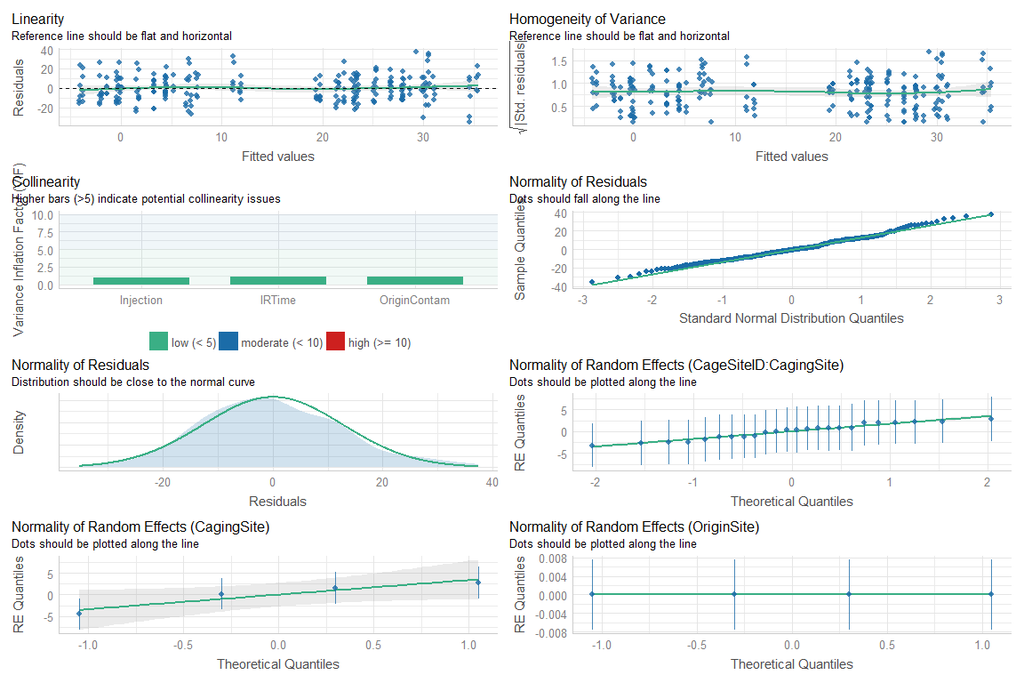

```r
mod5 <-
 lme4::lmer(
    IR ~ OriginContam + Injection + IRTime +
      (1 | CagingSite /  CageSiteID) + (1| OriginSite),
    data = dat2,
    na.action = na.exclude
  )
performance::check_model(mod5)
```

```r
car::Anova(mod5, type = "3")
```

```
## Analysis of Deviance Table (Type III Wald chisquare tests)
##
## Response: IR
##                 Chisq Df Pr(>Chisq)
## (Intercept)    1.7985  1    0.17990
## OriginContam   5.9245  1    0.01493 *
## Injection    199.6451  1    < 2e-16 ***
## IRTime         1.9059  1    0.16742
## ---
## Signif. codes:  0 '***' 0.001 '**' 0.01 '*' 0.05 '.' 0.1 ' ' 1
```

```r
summary(mod5)
```

```
## Linear mixed model fit by REML ['lmerMod']
## Formula:
## IR ~ OriginContam + Injection + IRTime + (1 | CagingSite/CageSiteID) +
##     (1 | OriginSite)
##    Data: dat2
##
## REML criterion at convergence: 1983.3
##
## Scaled residuals:
##      Min       1Q   Median       3Q      Max
## -2.69902 -0.68555 -0.06849  0.67737  2.85502
##
## Random effects:
##  Groups                Name        Variance  Std.Dev.
##  CageSiteID:CagingSite (Intercept) 9.957e+00  3.155436
##  CagingSite            (Intercept) 1.626e+01  4.032053
##  OriginSite            (Intercept) 1.502e-05  0.003876
##  Residual                          1.709e+02 13.072306
## Number of obs: 249, groups:
## CageSiteID:CagingSite, 24; CagingSite, 4; OriginSite, 4
##
## Fixed effects:
##                Estimate Std. Error t value
## (Intercept)    -968.190    721.950  -1.341
## OriginContamLC   -5.297      2.176  -2.434
## InjectionPBS    -23.495      1.663 -14.130
## IRTime           20.809     15.073   1.381
##
## Correlation of Fixed Effects:
##             (Intr) OrgCLC InjPBS
## OrignCntmLC  0.254
## InjectinPBS  0.004  0.024
## IRTime      -1.000 -0.255 -0.005
## optimizer (nloptwrap) convergence code: 0 (OK)
## unable to evaluate scaled gradient
## Model failed to converge: degenerate  Hessian with 1 negative eigenvalues
```